# Spotify - Music of the Future

Rachel Liu, Bohan Jiang, Dapo Folami, Justin Li

December 9th, 2020

##### *Note that it may take a significant amount of time and processing power to run this entire notebook, due to the number of models trained.*

## **Project Value and Impact**

The overarching objective for this project is to predict the next hit songs and understand what features drives popularity over time. This will give music professionals (music producer, song writer, singer, etc) a data-driven approach to be successful in the industry. In order to do this, we will be analyzing different variable relations, music trends over different decades, and feature significance with popularity. In the next few sections, we have shown in details different steps to clean the dataset, draw different insights/visualization based on initial analysis of the data, and create two predictive models to meet our objective.

## **Data Set Description**

For this project, our team decided to take a data-driven approach to evaluate music. We are using the Spotify Dataset from 1921 to 2020 that consists of over 160,000 different tracks (from Kaggle). In order to stay consistent in the evaluation, all data was sourced from the Spotify Web API. The following set of data is combination of Primary, Numerical, Dummy(binary), and Categorical data. This allows us to explore different types of models and draw different insights. Here are all the variables that is included in the data set:

**Primary Key**

- id: this an unique key comprised of numbers and characters that is assigned to each track generated by Spotify

**Numerical**

- acousticness: range from 0(LOW) to 1(HIGH)
- danceability: range from 0(LOW) to 1(HIGH)
- energy: range from 0(LOW) to 1(HIGH)
- duration_ms: majority range from 200,000 to 300,000
- instrumentalness: range from 0(LOW) to 1(HIGH)
- valence: range from 0(LOW) to 1(HIGH)
- popularity: range from 0(LOW) to 100(HIGH). The popularity is calculated by algorithm and is based, in the most part, on the total number of plays the track has had and how recent those plays are.Generally speaking, songs that are being played a lot now will have a higher popularity than songs that were played a lot in the past. Duplicate tracks (e.g. the same track from a single and an album) are rated independently. This is the main dependent variable.
- tempo: majority range from 50(LOW) to 150(HIGH)
- liveness: range from 0(LOW) to 1(HIGH)
- loudness majority range from -60 to 0
- speechiness: range from 0(LOW) to 1(HIGH)
- year: range from 1921 to 2020

**Dummy/Binary**

- mode: 0 represents minor and 1 represents major
- explicit: 0 represents no explicit content and 1 represents explicit content

**Categorical**

- key: this consists of all different music keys on octave encoded from 0 to 11 (i.e. C = 0, C# = 1, etc…)
- artists: the artist of the track
- release_date: the date of release in yyyy-mm-dd format
- name: the name of the track

#### Further documentation for a specific description for each of the audio features can be found [here](https://developer.spotify.com/documentation/web-api/reference/tracks/get-audio-features/).

Install all necessary packages before running this notebook.

```r
# Install all necessary packages
pkgs = c("ggplot2", "dplyr", "plotly","hrbrthemes","forecast","xts","Metrics","psych","dygraphs","GGally","tidyverse","tidyquant","cranlogs","corrr","cowplot","gplots","plm","lubridate","fastDummies","randomForest","randomForest","doParallel","caret","neuralnet","xgboost","h2o","readr","plyr","formattable","RWeka","qdap","tm","magrittr","corrplot","treemap","viridisLite","factoextra","gridExtra","kableExtra", "smooth", "nnfor")
install.packages(pkgs)
```

```
Error in install.packages : Updating loaded packages
```

Import all required libraries to run this notebook.

```r
# Libraries
options(warn=-1)
suppressPackageStartupMessages({
library(ggplot2)
library(dplyr)
library(plotly)
library(hrbrthemes)
library(forecast)
library(xts)
library(Metrics)
library(psych)
library(dygraphs)
library(GGally)
library(tidyverse)
library(tidyquant)
library(cranlogs)
library(corrr)
library(cowplot)
library(gplots)
library(plm)
library(lubridate)
library(fastDummies)
library(randomForest)
library(doParallel)
library(caret)
library(neuralnet)
library(xgboost)
library(h2o)
library(readr)
library(plyr)
library(formattable)
library(RWeka)
library(qdap)
library(tm)
library(magrittr)
library(corrplot)
library(treemap)
library(viridisLite)
library(factoextra)
library(gridExtra)
library(kableExtra)
library(smooth)
library(nnfor)
})
```

Change display options when printing matrices.

```r
options(repr.matrix.max.rows=100, repr.matrix.max.cols=20)
```

## **Data Import, Summary and Cleaning**

#### Import all datasets into dataframes.

```r
#Import datasets into DFs

# This is the main dataset that contains all unique songs
df = read.csv(file='./data/data.csv')

# Dataset that groups songs by genres
df_genre = read.csv(file='./data/data_by_genres.csv')

# Dataset that groups songs by artist
df_artist = read.csv(file='./data/data_by_artist.csv')

# Dataset that groups songs by year
df_year = read.csv(file='./data/data_by_year.csv')

# Dataset that group songs by artist and genre
df_genres2 = read.csv(file='./data/data_w_genres.csv')
```

```r
# Preview all DFs
head(df)
```

|  | acousticness | artists | danceability | duration_ms | energy | explicit | id | instrumentalness | key | liveness | loudness | mode | name | popularity | release_date | speechiness | tempo | valence | year |
| --- | --- | --- | --- | --- | --- | --- | --- | --- | --- | --- | --- | --- | --- | --- | --- | --- | --- | --- | --- |
| 1 | 0.732 | ['Dennis Day'] | 0.819 | 180533 | 0.341 | 0 | 7xPhfUan2yNtyFG0cUWkt8 | 0.00e+00 | 7 | 0.1600 | -12.441 | 1 | Clancy Lowered the Boom | 7 | 1921 | 0.4150 | 60.936 | 0.9630 | 1921 |
| 2 | 0.982 | ['Sergei Rachmaninoff', 'James Levine', 'Berliner Philharmoniker'] | 0.279 | 831667 | 0.211 | 0 | 4BJqT0PrAfrxzMOxytFOIz | 8.78e-01 | 10 | 0.6650 | -20.096 | 1 | Piano Concerto No. 3 in D Minor, Op. 30: III. Finale. Alla breve | 5 | 1921 | 0.0366 | 80.954 | 0.0594 | 1921 |
| 3 | 0.941 | ['Dennis Day'] | 0.241 | 196307 | 0.274 | 0 | 4aVy85Y2sxMwIKmAcimHp0 | 7.53e-06 | 0 | 0.0984 | -9.750 | 0 | How Can You Buy Killarny | 2 | 1921 | 0.0297 | 90.773 | 0.2120 | 1921 |
| 4 | 0.957 | ['Phil Regan'] | 0.418 | 166693 | 0.193 | 0 | 4d6HGyGT8e121BsdKmw9v6 | 1.68e-06 | 3 | 0.2290 | -10.096 | 1 | When Irish Eyes Are Smiling | 2 | 1921 | 0.0380 | 101.665 | 0.2530 | 1921 |
| 5 | 0.996 | ['John McCormack'] | 0.518 | 159507 | 0.203 | 0 | 5uNZnElqOS3W4fRmRYPk4T | 0.00e+00 | 0 | 0.1150 | -10.589 | 1 | The Wearing of the Green | 5 | 1921 | 0.0615 | 66.221 | 0.4060 | 1921 |
| 6 | 0.993 | ['Sergei Rachmaninoff'] | 0.389 | 218773 | 0.088 | 0 | 02GDntOXexBFUvSgaXLPkd | 5.27e-01 | 1 | 0.3630 | -21.091 | 0 | Morceaux de fantaisie, Op. 3: No. 2, PrÃ©lude in C-Sharp Minor. Lento | 2 | 1921 | 0.0456 | 92.867 | 0.0731 | 1921 |

```r
head(df_genre)
```

|  | genres | acousticness | danceability | duration_ms | energy | instrumentalness | liveness | loudness | speechiness | tempo | valence | popularity | key | mode |
| --- | --- | --- | --- | --- | --- | --- | --- | --- | --- | --- | --- | --- | --- | --- |
| 1 | 432hz | 0.4947800 | 0.2993333 | 1048887.3 | 0.4506783 | 0.477761667 | 0.1310000 | -16.854000 | 0.07681667 | 120.2857 | 0.2217500 | 52.16667 | 5 | 1 |
| 2 | [] | 0.6792447 | 0.5214733 | 229852.6 | 0.4015221 | 0.196737314 | 0.2215862 | -12.679076 | 0.11226708 | 112.0252 | 0.5159200 | 21.68200 | 7 | 1 |
| 3 | a cappella | 0.6215317 | 0.5770169 | 193652.2 | 0.3456941 | 0.003798922 | 0.1270868 | -12.770211 | 0.09532427 | 111.8132 | 0.4531856 | 43.35182 | 11 | 1 |
| 4 | abstract | 0.3593950 | 0.4595000 | 343018.5 | 0.4870000 | 0.791400000 | 0.1194800 | -14.092000 | 0.04342000 | 124.7432 | 0.3049900 | 41.50000 | 1 | 1 |
| 5 | abstract beats | 0.3533467 | 0.6944000 | 233824.4 | 0.6134000 | 0.349402612 | 0.1024533 | -6.699800 | 0.14345333 | 119.3984 | 0.6341867 | 58.60000 | 10 | 0 |
| 6 | abstract hip hop | 0.2058720 | 0.7231316 | 249095.1 | 0.6454608 | 0.002852672 | 0.1680318 | -7.216007 | 0.25010439 | 112.1603 | 0.5843918 | 43.80497 | 11 | 1 |

```r
head(df_artist)
```

|  | artists | acousticness | danceability | duration_ms | energy | instrumentalness | liveness | loudness | speechiness | tempo | valence | popularity | key | mode | count |
| --- | --- | --- | --- | --- | --- | --- | --- | --- | --- | --- | --- | --- | --- | --- | --- |
| 1 | "Cats" 1981 Original London Cast | 0.5750833 | 0.4427500 | 247260.0 | 0.3863358 | 0.022717397 | 0.2877083 | -14.20542 | 0.18067500 | 115.98350 | 0.3344333 | 38.00000 | 5 | 1 | 12 |
| 2 | "Cats" 1983 Broadway Cast | 0.8625385 | 0.4417308 | 287280.0 | 0.4068077 | 0.081158264 | 0.3152154 | -10.69000 | 0.17621154 | 103.04415 | 0.2688654 | 33.07692 | 5 | 1 | 26 |
| 3 | "Fiddler On The Roofâ\200\235 Motion Picture Chorus | 0.8565714 | 0.3482857 | 328920.0 | 0.2865714 | 0.024592949 | 0.3257857 | -15.23071 | 0.11851429 | 77.37586 | 0.3548571 | 34.28571 | 0 | 1 | 7 |
| 4 | "Fiddler On The Roofâ\200\235 Motion Picture Orchestra | 0.8849259 | 0.4250741 | 262891.0 | 0.2457704 | 0.073587279 | 0.2754815 | -15.63937 | 0.12320000 | 88.66763 | 0.3720296 | 34.44444 | 0 | 1 | 27 |
| 5 | "Joseph And The Amazing Technicolor Dreamcoat" 1991 London Cast | 0.6054444 | 0.4373333 | 232428.1 | 0.4293333 | 0.037533560 | 0.2161111 | -11.44722 | 0.08600000 | 120.32967 | 0.4586667 | 42.55556 | 11 | 1 | 9 |
| 6 | "Joseph And The Amazing Technicolor Dreamcoat" 1992 Canadian Cast | 0.6095556 | 0.4872778 | 205091.9 | 0.3099056 | 0.004695657 | 0.2747667 | -18.26639 | 0.09802222 | 118.64894 | 0.4415556 | 34.16667 | 5 | 1 | 36 |

```r
head(df_year)
```

|  | year | acousticness | danceability | duration_ms | energy | instrumentalness | liveness | loudness | speechiness | tempo | valence | popularity | key | mode |
| --- | --- | --- | --- | --- | --- | --- | --- | --- | --- | --- | --- | --- | --- | --- |
| 1 | 1921 | 0.8958234 | 0.4256609 | 229911.9 | 0.2367836 | 0.3223301 | 0.2158141 | -17.09544 | 0.07725781 | 100.3978 | 0.4254945 | 0.3515625 | 7 | 1 |
| 2 | 1922 | 0.9392361 | 0.4800000 | 167904.5 | 0.2370262 | 0.4404699 | 0.2386472 | -19.17996 | 0.11541944 | 101.3761 | 0.5340556 | 0.1388889 | 10 | 1 |
| 3 | 1923 | 0.9763289 | 0.5684615 | 178356.3 | 0.2469361 | 0.4019325 | 0.2366556 | -14.37388 | 0.09861893 | 112.4566 | 0.6247876 | 5.7278107 | 0 | 1 |
| 4 | 1924 | 0.9355745 | 0.5486540 | 188461.6 | 0.3470329 | 0.5839547 | 0.2378747 | -14.20230 | 0.09020970 | 120.6534 | 0.6685738 | 0.6033755 | 10 | 1 |
| 5 | 1925 | 0.9654221 | 0.5718897 | 184130.7 | 0.2643726 | 0.4088934 | 0.2430935 | -14.51671 | 0.11545741 | 115.6717 | 0.6164304 | 2.7072243 | 5 | 1 |
| 6 | 1926 | 0.7409196 | 0.5582952 | 170391.5 | 0.2391949 | 0.4685053 | 0.2340525 | -16.41062 | 0.30667243 | 108.4966 | 0.4959615 | 1.6132723 | 5 | 1 |

```r
head(df_genres2)
```

|  | artists | acousticness | danceability | duration_ms | energy | instrumentalness | liveness | loudness | speechiness | tempo | valence | popularity | key | mode | count | genres |
| --- | --- | --- | --- | --- | --- | --- | --- | --- | --- | --- | --- | --- | --- | --- | --- | --- |
| 1 | "Cats" 1981 Original London Cast | 0.5750833 | 0.4427500 | 247260.0 | 0.3863358 | 0.022717397 | 0.2877083 | -14.20542 | 0.18067500 | 115.98350 | 0.3344333 | 38.00000 | 5 | 1 | 12 | ['show tunes'] |
| 2 | "Cats" 1983 Broadway Cast | 0.8625385 | 0.4417308 | 287280.0 | 0.4068077 | 0.081158264 | 0.3152154 | -10.69000 | 0.17621154 | 103.04415 | 0.2688654 | 33.07692 | 5 | 1 | 26 | [] |
| 3 | "Fiddler On The Roofâ\200\235 Motion Picture Chorus | 0.8565714 | 0.3482857 | 328920.0 | 0.2865714 | 0.024592949 | 0.3257857 | -15.23071 | 0.11851429 | 77.37586 | 0.3548571 | 34.28571 | 0 | 1 | 7 | [] |
| 4 | "Fiddler On The Roofâ\200\235 Motion Picture Orchestra | 0.8849259 | 0.4250741 | 262891.0 | 0.2457704 | 0.073587279 | 0.2754815 | -15.63937 | 0.12320000 | 88.66763 | 0.3720296 | 34.44444 | 0 | 1 | 27 | [] |
| 5 | "Joseph And The Amazing Technicolor Dreamcoat" 1991 London Cast | 0.6054444 | 0.4373333 | 232428.1 | 0.4293333 | 0.037533560 | 0.2161111 | -11.44722 | 0.08600000 | 120.32967 | 0.4586667 | 42.55556 | 11 | 1 | 9 | [] |
| 6 | "Joseph And The Amazing Technicolor Dreamcoat" 1992 Canadian Cast | 0.6095556 | 0.4872778 | 205091.9 | 0.3099056 | 0.004695657 | 0.2747667 | -18.26639 | 0.09802222 | 118.64894 | 0.4415556 | 34.16667 | 5 | 1 | 36 | [] |

#### Data Cleaning

```r
# Take only unique rows - remove duplicates
df <- df %>% distinct()
df_genre <- df_genre %>% distinct()
df_artist <- df_artist %>% distinct()
df_year <- df_year %>% distinct()
df_genres2 <- df_genres2 %>% distinct()

# Remove null rows in R
df <- df[rowSums(is.na(df)) == 0,]
df_genre <- df_genre[rowSums(is.na(df_genre)) == 0,]
df_artist <- df_artist[rowSums(is.na(df_artist)) == 0,]
df_year <- df_year[rowSums(is.na(df_year)) == 0,]
df_genres2 <- df_genres2[rowSums(is.na(df_genres2)) == 0,]

# Change year column to a double value for df and df_year
df$year <- as.Date(as.character(df$year), format = "%Y")
df$year = lubridate::year(df$year)

df_year$year <- as.Date(as.character(df_year$year), format = "%Y")
df_year$year = lubridate::year(df_year$year)
head(df)
```

|  | acousticness | artists | danceability | duration_ms | energy | explicit | id | instrumentalness | key | liveness | loudness | mode | name | popularity | release_date | speechiness | tempo | valence | year |
| --- | --- | --- | --- | --- | --- | --- | --- | --- | --- | --- | --- | --- | --- | --- | --- | --- | --- | --- | --- |
| 1 | 0.732 | ['Dennis Day'] | 0.819 | 180533 | 0.341 | 0 | 7xPhfUan2yNtyFG0cUWkt8 | 0.00e+00 | 7 | 0.1600 | -12.441 | 1 | Clancy Lowered the Boom | 7 | 1921 | 0.4150 | 60.936 | 0.9630 | 1921 |
| 2 | 0.982 | ['Sergei Rachmaninoff', 'James Levine', 'Berliner Philharmoniker'] | 0.279 | 831667 | 0.211 | 0 | 4BJqT0PrAfrxzMOxytFOIz | 8.78e-01 | 10 | 0.6650 | -20.096 | 1 | Piano Concerto No. 3 in D Minor, Op. 30: III. Finale. Alla breve | 5 | 1921 | 0.0366 | 80.954 | 0.0594 | 1921 |
| 3 | 0.941 | ['Dennis Day'] | 0.241 | 196307 | 0.274 | 0 | 4aVy85Y2sxMwIKmAcimHp0 | 7.53e-06 | 0 | 0.0984 | -9.750 | 0 | How Can You Buy Killarny | 2 | 1921 | 0.0297 | 90.773 | 0.2120 | 1921 |
| 4 | 0.957 | ['Phil Regan'] | 0.418 | 166693 | 0.193 | 0 | 4d6HGyGT8e121BsdKmw9v6 | 1.68e-06 | 3 | 0.2290 | -10.096 | 1 | When Irish Eyes Are Smiling | 2 | 1921 | 0.0380 | 101.665 | 0.2530 | 1921 |
| 5 | 0.996 | ['John McCormack'] | 0.518 | 159507 | 0.203 | 0 | 5uNZnElqOS3W4fRmRYPk4T | 0.00e+00 | 0 | 0.1150 | -10.589 | 1 | The Wearing of the Green | 5 | 1921 | 0.0615 | 66.221 | 0.4060 | 1921 |
| 6 | 0.993 | ['Sergei Rachmaninoff'] | 0.389 | 218773 | 0.088 | 0 | 02GDntOXexBFUvSgaXLPkd | 5.27e-01 | 1 | 0.3630 | -21.091 | 0 | Morceaux de fantaisie, Op. 3: No. 2, PrÃ©lude in C-Sharp Minor. Lento | 2 | 1921 | 0.0456 | 92.867 | 0.0731 | 1921 |

```r
head(df_year)
```

|  | year | acousticness | danceability | duration_ms | energy | instrumentalness | liveness | loudness | speechiness | tempo | valence | popularity | key | mode |
| --- | --- | --- | --- | --- | --- | --- | --- | --- | --- | --- | --- | --- | --- | --- |
| 1 | 1921 | 0.8958234 | 0.4256609 | 229911.9 | 0.2367836 | 0.3223301 | 0.2158141 | -17.09544 | 0.07725781 | 100.3978 | 0.4254945 | 0.3515625 | 7 | 1 |
| 2 | 1922 | 0.9392361 | 0.4800000 | 167904.5 | 0.2370262 | 0.4404699 | 0.2386472 | -19.17996 | 0.11541944 | 101.3761 | 0.5340556 | 0.1388889 | 10 | 1 |
| 3 | 1923 | 0.9763289 | 0.5684615 | 178356.3 | 0.2469361 | 0.4019325 | 0.2366556 | -14.37388 | 0.09861893 | 112.4566 | 0.6247876 | 5.7278107 | 0 | 1 |
| 4 | 1924 | 0.9355745 | 0.5486540 | 188461.6 | 0.3470329 | 0.5839547 | 0.2378747 | -14.20230 | 0.09020970 | 120.6534 | 0.6685738 | 0.6033755 | 10 | 1 |
| 5 | 1925 | 0.9654221 | 0.5718897 | 184130.7 | 0.2643726 | 0.4088934 | 0.2430935 | -14.51671 | 0.11545741 | 115.6717 | 0.6164304 | 2.7072243 | 5 | 1 |
| 6 | 1926 | 0.7409196 | 0.5582952 | 170391.5 | 0.2391949 | 0.4685053 | 0.2340525 | -16.41062 | 0.30667243 | 108.4966 | 0.4959615 | 1.6132723 | 5 | 1 |

#### Data Summary of all Datasets

```r
# Get summary of main dataframe

# Data Dimensions, Column names, column types, preview of data
glimpse(df)
```

```
Rows: 169,909
Columns: 19
$ acousticness     <dbl> 0.7320, 0.9820, 0.9410, 0.9570, 0.9960, 0.9930, 0.9960, 0.9820, 0.9950, 0.9940, 0.9900, 0.9120, 0.0175, 0.9890, 0.9570,...
$ artists          <chr> "['Dennis Day']", "['Sergei Rachmaninoff', 'James Levine', 'Berliner Philharmoniker']", "['Dennis Day']", "['Phil Regan...
$ danceability     <dbl> 0.8190, 0.2790, 0.2410, 0.4180, 0.5180, 0.3890, 0.4850, 0.6840, 0.4630, 0.3780, 0.3150, 0.4150, 0.5270, 0.3840, 0.2590,...
$ duration_ms      <int> 180533, 831667, 196307, 166693, 159507, 218773, 161520, 196560, 147133, 155413, 190800, 184973, 205072, 221013, 186467,...
$ energy           <dbl> 0.3410, 0.2110, 0.2740, 0.1930, 0.2030, 0.0880, 0.1300, 0.2570, 0.2600, 0.1150, 0.3630, 0.4200, 0.6910, 0.1710, 0.2120,...
$ explicit         <int> 0, 0, 0, 0, 0, 0, 0, 0, 0, 0, 0, 0, 1, 0, 0, 0, 1, 0, 0, 0, 0, 0, 0, 0, 0, 0, 0, 0, 0, 0, 0, 0, 0, 0, 0, 0, 1, 0, 0, 0,...
$ id               <chr> "7xPhfUan2yNtyFG0cUWkt8", "4BJqT0PrAfrxzMOxytFOIz", "4aVy85Y2sxMwIKmAcimHp0", "4d6HGyGT8e121BsdKmw9v6", "5uNZnElqOS3W4f...
$ instrumentalness <dbl> 0.00e+00, 8.78e-01, 7.53e-06, 1.68e-06, 0.00e+00, 5.27e-01, 1.51e-01, 0.00e+00, 0.00e+00, 9.06e-01, 0.00e+00, 8.90e-01,...
$ key              <int> 7, 10, 0, 3, 0, 1, 5, 8, 9, 10, 5, 8, 7, 7, 2, 9, 4, 5, 10, 4, 11, 7, 4, 1, 2, 4, 2, 7, 0, 4, 9, 6, 9, 5, 0, 10, 1, 10,...
$ liveness         <dbl> 0.1600, 0.6650, 0.0984, 0.2290, 0.1150, 0.3630, 0.1040, 0.5040, 0.2580, 0.1100, 0.2920, 0.1080, 0.3580, 0.1160, 0.2360,...
$ loudness         <dbl> -12.441, -20.096, -9.750, -10.096, -10.589, -21.091, -21.508, -16.415, -16.894, -27.039, -12.562, -10.766, -7.298, -20....
$ mode             <int> 1, 1, 0, 1, 1, 0, 0, 1, 1, 0, 0, 0, 1, 0, 1, 1, 0, 0, 0, 1, 1, 1, 1, 0, 1, 0, 1, 1, 1, 0, 1, 0, 1, 1, 0, 1, 1, 0, 0, 1,...
$ name             <chr> "Clancy Lowered the Boom", "Piano Concerto No. 3 in D Minor, Op. 30: III. Finale. Alla breve", "How Can You Buy Killarn...
$ popularity       <int> 7, 5, 2, 2, 5, 2, 0, 0, 0, 0, 0, 0, 0, 3, 1, 0, 0, 0, 0, 0, 0, 0, 0, 0, 0, 0, 0, 0, 0, 0, 0, 0, 0, 1, 0, 2, 0, 0, 0, 0,...
$ release_date     <chr> "1921", "1921", "1921", "1921", "1921", "1921", "3/20/1921", "1921", "1921", "3/20/1921", "1921", "1921", "3/27/1921", ...
$ speechiness      <dbl> 0.4150, 0.0366, 0.0297, 0.0380, 0.0615, 0.0456, 0.0483, 0.3990, 0.0557, 0.0414, 0.0546, 0.1140, 0.0326, 0.0319, 0.0358,...
$ tempo            <dbl> 60.936, 80.954, 90.773, 101.665, 66.221, 92.867, 64.678, 109.378, 85.146, 70.370, 174.532, 70.758, 159.935, 107.698, 85...
$ valence          <dbl> 0.9630, 0.0594, 0.2120, 0.2530, 0.4060, 0.0731, 0.7210, 0.7710, 0.8260, 0.5780, 0.4930, 0.2120, 0.4930, 0.2820, 0.2180,...
$ year             <dbl> 1921, 1921, 1921, 1921, 1921, 1921, 1921, 1921, 1921, 1921, 1921, 1921, 1921, 1921, 1921, 1921, 1921, 1921, 1921, 1921,...
```

```r
# Statistical summary of every column
summary(df)
```

```
  acousticness      artists           danceability     duration_ms          energy          explicit            id            instrumentalness
 Min.   :0.0000   Length:169909      Min.   :0.0000   Min.   :   5108   Min.   :0.0000   Min.   :0.00000   Length:169909      Min.   :0.000000
 1st Qu.:0.0945   Class :character   1st Qu.:0.4170   1st Qu.: 171040   1st Qu.:0.2630   1st Qu.:0.00000   Class :character   1st Qu.:0.000000
 Median :0.4920   Mode  :character   Median :0.5480   Median : 208600   Median :0.4810   Median :0.00000   Mode  :character   Median :0.000204
 Mean   :0.4932                      Mean   :0.5381   Mean   : 231406   Mean   :0.4886   Mean   :0.08486                      Mean   :0.161937
 3rd Qu.:0.8880                      3rd Qu.:0.6670   3rd Qu.: 262960   3rd Qu.:0.7100   3rd Qu.:0.00000                      3rd Qu.:0.086800
 Max.   :0.9960                      Max.   :0.9880   Max.   :5403500   Max.   :1.0000   Max.   :1.00000                      Max.   :1.000000
      key            liveness         loudness            mode            name             popularity     release_date        speechiness
 Min.   : 0.000   Min.   :0.0000   Min.   :-60.000   Min.   :0.0000   Length:169909      Min.   :  0.00   Length:169909      Min.   :0.00000
 1st Qu.: 2.000   1st Qu.:0.0984   1st Qu.:-14.470   1st Qu.:0.0000   Class :character   1st Qu.: 12.00   Class :character   1st Qu.:0.03490
 Median : 5.000   Median :0.1350   Median :-10.474   Median :1.0000   Mode  :character   Median : 33.00   Mode  :character   Median :0.04500
 Mean   : 5.201   Mean   :0.2067   Mean   :-11.370   Mean   :0.7086                      Mean   : 31.56                      Mean   :0.09406
 3rd Qu.: 8.000   3rd Qu.:0.2630   3rd Qu.: -7.118   3rd Qu.:1.0000                      3rd Qu.: 48.00                      3rd Qu.:0.07540
 Max.   :11.000   Max.   :1.0000   Max.   :  3.855   Max.   :1.0000                      Max.   :100.00                      Max.   :0.96900
     tempo           valence            year
 Min.   :  0.00   Min.   :0.0000   Min.   :1921
 1st Qu.: 93.52   1st Qu.:0.3220   1st Qu.:1957
 Median :114.78   Median :0.5440   Median :1978
 Mean   :116.95   Mean   :0.5321   Mean   :1977
 3rd Qu.:135.71   3rd Qu.:0.7490   3rd Qu.:1999
 Max.   :244.09   Max.   :1.0000   Max.   :2020
```

```r
# Print all column names
colnames(df)
```

```
 [1] "acousticness"     "artists"          "danceability"     "duration_ms"      "energy"           "explicit"         "id"
 [8] "instrumentalness" "key"              "liveness"         "loudness"         "mode"             "name"             "popularity"
[15] "release_date"     "speechiness"      "tempo"            "valence"          "year"
```

The above dataset is an unbalanced dataset with differing quantities of cross-sectional observations of new songs every year, from 1921 - 2020.

```r
# Get summary of dataframe by year

# Data Dimensions, Column names, column types, preview of data
glimpse(df_year)
```

```
Rows: 100
Columns: 14
$ year             <dbl> 1921, 1922, 1923, 1924, 1925, 1926, 1927, 1928, 1929, 1930, 1931, 1932, 1933, 1934, 1935, 1936, 1937, 1938, 1939, 1940,...
$ acousticness     <dbl> 0.8958234, 0.9392361, 0.9763289, 0.9355745, 0.9654221, 0.7409196, 0.9346063, 0.9461880, 0.5911105, 0.9434742, 0.8758935...
$ danceability     <dbl> 0.4256609, 0.4800000, 0.5684615, 0.5486540, 0.5718897, 0.5582952, 0.6499597, 0.5296957, 0.6470051, 0.5103822, 0.5560935...
$ duration_ms      <dbl> 229911.9, 167904.5, 178356.3, 188461.6, 184130.7, 170391.5, 185163.2, 217498.3, 169983.4, 195908.6, 179379.6, 193462.7,...
$ energy           <dbl> 0.2367836, 0.2370262, 0.2469361, 0.3470329, 0.2643726, 0.2391949, 0.2561587, 0.2071427, 0.2405134, 0.3273002, 0.2584340...
$ instrumentalness <dbl> 0.3223301, 0.4404699, 0.4019325, 0.5839547, 0.4088934, 0.4685053, 0.4022758, 0.5169790, 0.2194613, 0.3633766, 0.3320111...
$ liveness         <dbl> 0.2158141, 0.2386472, 0.2366556, 0.2378747, 0.2430935, 0.2340525, 0.1677785, 0.1779883, 0.2359883, 0.2173204, 0.2391179...
$ loudness         <dbl> -17.09544, -19.17996, -14.37388, -14.20230, -14.51671, -16.41062, -14.72681, -17.31619, -16.60709, -12.68593, -15.90358...
$ speechiness      <dbl> 0.07725781, 0.11541944, 0.09861893, 0.09020970, 0.11545741, 0.30667243, 0.11619748, 0.13531327, 0.48527835, 0.07970237,...
$ tempo            <dbl> 100.3978, 101.3761, 112.4566, 120.6534, 115.6717, 108.4966, 114.6115, 106.1952, 111.3540, 110.2144, 108.0103, 116.2258,...
$ valence          <dbl> 0.4254945, 0.5340556, 0.6247876, 0.6685738, 0.6164304, 0.4959615, 0.6606591, 0.4929536, 0.6382077, 0.6184582, 0.5713130...
$ popularity       <dbl> 0.3515625, 0.1388889, 5.7278107, 0.6033755, 2.7072243, 1.6132723, 0.8322148, 1.5367709, 0.3279221, 0.8715546, 0.2116904...
$ key              <int> 7, 10, 0, 10, 5, 5, 7, 1, 7, 2, 0, 7, 5, 0, 7, 10, 7, 0, 0, 7, 7, 7, 5, 10, 0, 7, 0, 0, 0, 7, 0, 5, 0, 5, 0, 0, 5, 0, 0...
$ mode             <int> 1, 1, 1, 1, 1, 1, 1, 1, 1, 1, 1, 1, 1, 1, 1, 1, 1, 1, 1, 1, 1, 1, 1, 1, 1, 1, 1, 1, 1, 1, 1, 1, 1, 1, 1, 1, 1, 1, 1, 1,...
```

```r
# Statistical summary of every column
summary(df_year)
```

```
      year       acousticness     danceability     duration_ms         energy       instrumentalness     liveness         loudness
 Min.   :1921   Min.   :0.2287   Min.   :0.4035   Min.   :167905   Min.   :0.2043   Min.   :0.03595   Min.   :0.1672   Min.   :-19.180
 1st Qu.:1946   1st Qu.:0.2827   1st Qu.:0.5002   1st Qu.:208883   1st Qu.:0.2862   1st Qu.:0.09880   1st Qu.:0.1987   1st Qu.:-14.309
 Median :1970   Median :0.4530   Median :0.5447   Median :234674   Median :0.4987   Median :0.12492   Median :0.2079   Median :-11.762
 Mean   :1970   Mean   :0.5526   Mean   :0.5375   Mean   :226930   Mean   :0.4559   Mean   :0.19216   Mean   :0.2093   Mean   :-11.917
 3rd Qu.:1995   3rd Qu.:0.8670   3rd Qu.:0.5717   3rd Qu.:248234   3rd Qu.:0.6010   3rd Qu.:0.27776   3rd Qu.:0.2204   3rd Qu.: -9.716
 Max.   :2020   Max.   :0.9763   Max.   :0.6731   Max.   :266388   Max.   :0.6937   Max.   :0.58395   Max.   :0.2643   Max.   : -6.694
  speechiness          tempo          valence         popularity           key             mode
 Min.   :0.05105   Min.   :100.4   Min.   :0.3736   Min.   : 0.1389   Min.   : 0.00   Min.   :1
 1st Qu.:0.06512   1st Qu.:111.8   1st Qu.:0.4958   1st Qu.: 2.9396   1st Qu.: 0.00   1st Qu.:1
 Median :0.08624   Median :117.6   Median :0.5480   Median :33.6555   Median : 5.00   Median :1
 Mean   :0.10125   Mean   :116.0   Mean   :0.5364   Mean   :27.2232   Mean   : 4.19   Mean   :1
 3rd Qu.:0.10496   3rd Qu.:120.8   3rd Qu.:0.5745   3rd Qu.:44.4111   3rd Qu.: 7.00   3rd Qu.:1
 Max.   :0.48528   Max.   :123.7   Max.   :0.6686   Max.   :69.6555   Max.   :10.00   Max.   :1
```

```r
# Print all column names
colnames(df_year)
```

```
 [1] "year"             "acousticness"     "danceability"     "duration_ms"      "energy"           "instrumentalness" "liveness"
 [8] "loudness"         "speechiness"      "tempo"            "valence"          "popularity"       "key"              "mode"
```

The above dataset is grouped by year, with one row of observation per year from 1921-2020. The mean value of all the songs in a given year is used to group the various songs in each year. However, there seems to be an issue with the mode feature, which is 1 throughout the dataset.

```r
# Get summary of dataframe by genre

# Data Dimensions, Column names, column types, preview of data
glimpse(df_genre)
```

```
Rows: 2,664
Columns: 14
$ genres           <chr> "432hz", "[]", "a cappella", "abstract", "abstract beats", "abstract hip hop", "accordeon", "accordion", "acid house", ...
$ acousticness     <dbl> 0.49478000, 0.67924474, 0.62153172, 0.35939500, 0.35334667, 0.20587199, 0.80133333, 0.48620833, 0.05700233, 0.15541400,...
$ danceability     <dbl> 0.2993333, 0.5214733, 0.5770169, 0.4595000, 0.6944000, 0.7231316, 0.6263333, 0.6408333, 0.6842278, 0.7142000, 0.4535411...
$ duration_ms      <dbl> 1048887.3, 229852.6, 193652.2, 343018.5, 233824.4, 249095.1, 162613.3, 166508.2, 293609.3, 284362.4, 252930.7, 216060.0...
$ energy           <dbl> 0.4506783, 0.4015221, 0.3456941, 0.4870000, 0.6134000, 0.6454608, 0.3090000, 0.3640000, 0.7214189, 0.6946667, 0.5920554...
$ instrumentalness <dbl> 4.777617e-01, 1.967373e-01, 3.798922e-03, 7.914000e-01, 3.494026e-01, 2.852672e-03, 6.160000e-01, 1.113173e-01, 3.20219...
$ liveness         <dbl> 0.13100000, 0.22158621, 0.12708682, 0.11948000, 0.10245333, 0.16803175, 0.25266667, 0.18697500, 0.23238111, 0.10680000,...
$ loudness         <dbl> -16.854000, -12.679076, -12.770211, -14.092000, -6.699800, -7.216007, -10.736667, -14.436542, -10.378311, -10.234667, -...
$ speechiness      <dbl> 0.07681667, 0.11226708, 0.09532427, 0.04342000, 0.14345333, 0.25010439, 0.03573333, 0.08277500, 0.05850944, 0.05202000,...
$ tempo            <dbl> 120.28567, 112.02517, 111.81323, 124.74320, 119.39840, 112.16029, 114.52200, 112.72217, 123.17593, 112.24340, 125.46594...
$ valence          <dbl> 0.2217500, 0.5159200, 0.4531856, 0.3049900, 0.6341867, 0.5843918, 0.5436667, 0.6439167, 0.6222056, 0.7893667, 0.5359745...
$ popularity       <dbl> 52.166667, 21.682005, 43.351819, 41.500000, 58.600000, 43.804971, 28.666667, 15.208333, 44.566667, 44.033333, 34.500012...
$ key              <int> 5, 7, 11, 1, 10, 11, 2, 2, 11, 6, 9, 2, 0, 7, 11, 9, 7, 0, 6, 7, 4, 0, 7, 8, 11, 5, 1, 7, 0, 0, 6, 9, 7, 7, 11, 1, 7, 6...
$ mode             <int> 1, 1, 1, 1, 0, 1, 1, 1, 1, 1, 1, 1, 1, 1, 1, 1, 1, 1, 1, 1, 1, 0, 1, 1, 1, 1, 1, 1, 1, 1, 0, 1, 0, 1, 0, 1, 1, 1, 1, 0,...
```

```r
# Statistical summary of every column
summary(df_genre)
```

```
    genres           acousticness        danceability      duration_ms          energy         instrumentalness      liveness
 Length:2664        Min.   :0.0000033   Min.   :0.05985   Min.   :  30946   Min.   :0.002825   Min.   :0.000000   Min.   :0.0222
 Class :character   1st Qu.:0.1200519   1st Qu.:0.44585   1st Qu.: 205414   1st Qu.:0.403441   1st Qu.:0.005402   1st Qu.:0.1448
 Mode  :character   Median :0.3196123   Median :0.54478   Median : 237096   Median :0.600476   Median :0.077899   Median :0.1800
                    Mean   :0.3990600   Mean   :0.53655   Mean   : 249383   Mean   :0.564704   Mean   :0.200024   Mean   :0.1939
                    3rd Qu.:0.6578291   3rd Qu.:0.64312   3rd Qu.: 272314   3rd Qu.:0.733009   3rd Qu.:0.320169   3rd Qu.:0.2203
                    Max.   :0.9960000   Max.   :0.95733   Max.   :1644773   Max.   :0.999500   Max.   :0.992000   Max.   :0.9270
    loudness         speechiness          tempo           valence           popularity         key              mode
 Min.   :-37.6135   Min.   :0.02250   Min.   : 37.76   Min.   :0.004886   Min.   : 0.00   Min.   : 0.000   Min.   :0.0000
 1st Qu.:-12.3871   1st Qu.:0.04543   1st Qu.:109.29   1st Qu.:0.362073   1st Qu.:33.00   1st Qu.: 3.000   1st Qu.:1.0000
 Median : -9.2884   Median :0.06038   Median :118.75   Median :0.508720   Median :43.00   Median : 7.000   Median :1.0000
 Mean   :-10.3766   Mean   :0.08375   Mean   :118.85   Mean   :0.499292   Mean   :40.12   Mean   : 5.916   Mean   :0.8431
 3rd Qu.: -6.9452   3rd Qu.:0.09033   3rd Qu.:127.20   3rd Qu.:0.638521   3rd Qu.:50.88   3rd Qu.: 9.000   3rd Qu.:1.0000
 Max.   : -0.1315   Max.   :0.94093   Max.   :210.09   Max.   :0.980000   Max.   :82.00   Max.   :11.000   Max.   :1.0000
```

```r
# Print all column names
colnames(df_genre)
```

```
 [1] "genres"           "acousticness"     "danceability"     "duration_ms"      "energy"           "instrumentalness" "liveness"
 [8] "loudness"         "speechiness"      "tempo"            "valence"          "popularity"       "key"              "mode"
```

The above dataset is grouped by genre, with no time-series component. The mean value of all songs of a given genre is used to group the dataset.

```r
# Get summary of dataframe by artist

# Data Dimensions, Column names, column types, preview of data
glimpse(df_artist)
```

```
Rows: 27,621
Columns: 15
$ artists          <chr> "\"Cats\" 1981 Original London Cast", "\"Cats\" 1983 Broadway Cast", "\"Fiddler On The Roofâ\200\235 Motion Picture Cho...
$ acousticness     <dbl> 0.57508333, 0.86253846, 0.85657143, 0.88492593, 0.60544444, 0.60955556, 0.72500000, 0.00690000, 0.92700000, 0.17693409,...
$ danceability     <dbl> 0.4427500, 0.4417308, 0.3482857, 0.4250741, 0.4373333, 0.4872778, 0.6370000, 0.8490000, 0.7340000, 0.6647879, 0.8066667...
$ duration_ms      <dbl> 247260.00, 287280.00, 328920.00, 262890.96, 232428.11, 205091.94, 135533.00, 123040.00, 175693.00, 218165.26, 66307.33,...
$ energy           <dbl> 0.3863358, 0.4068077, 0.2865714, 0.2457704, 0.4293333, 0.3099056, 0.5120000, 0.4870000, 0.4740000, 0.6851364, 0.4690000...
$ instrumentalness <dbl> 2.271740e-02, 8.115826e-02, 2.459295e-02, 7.358728e-02, 3.753356e-02, 4.695657e-03, 1.860000e-01, 4.640000e-01, 7.62000...
$ liveness         <dbl> 0.2877083, 0.3152154, 0.3257857, 0.2754815, 0.2161111, 0.2747667, 0.4260000, 0.1460000, 0.7370000, 0.1621394, 0.2043333...
$ loudness         <dbl> -14.205417, -10.690000, -15.230714, -15.639370, -11.447222, -18.266389, -20.615000, -9.664000, -10.544000, -9.877909, -...
$ speechiness      <dbl> 0.18067500, 0.17621154, 0.11851429, 0.12320000, 0.08600000, 0.09802222, 0.21000000, 0.35100000, 0.25600000, 0.08239242,...
$ tempo            <dbl> 115.98350, 103.04415, 77.37586, 88.66763, 120.32967, 118.64894, 134.81900, 170.98100, 132.78800, 132.49509, 106.02000, ...
$ valence          <dbl> 0.3344333, 0.2688654, 0.3548571, 0.3720296, 0.4586667, 0.4415556, 0.8850000, 0.4990000, 0.9020000, 0.7544091, 0.5920000...
$ popularity       <dbl> 38.00000, 33.07692, 34.28571, 34.44444, 42.55556, 34.16667, 0.00000, 36.00000, 2.00000, 33.68182, 62.66667, 64.62500, 5...
$ key              <int> 5, 5, 0, 0, 11, 5, 8, 4, 10, 9, 6, 6, 7, 1, 3, 7, 8, 10, 1, 0, 3, 0, 5, 4, 2, 0, 2, 10, 7, 1, 1, 4, 2, 6, 9, 6, 9, 6, 9...
$ mode             <int> 1, 1, 1, 1, 1, 1, 1, 0, 1, 1, 0, 1, 1, 1, 1, 1, 1, 1, 1, 1, 1, 1, 1, 0, 1, 1, 1, 0, 1, 1, 0, 0, 0, 1, 1, 1, 1, 0, 1, 0,...
$ count            <int> 12, 26, 7, 27, 9, 36, 2, 1, 2, 132, 6, 8, 1, 122, 1, 17, 12, 2, 2, 16, 2, 2, 2, 3, 10, 78, 8, 2, 2, 2, 5, 3, 4, 16, 44,...
```

```r
# Statistical summary of every column
summary(df_artist)
```

```
   artists           acousticness     danceability     duration_ms          energy       instrumentalness      liveness         loudness
 Length:27621       Min.   :0.0000   Min.   :0.0000   Min.   :  18796   Min.   :0.0000   Min.   :0.000000   Min.   :0.0000   Min.   :-60.000
 Class :character   1st Qu.:0.1288   1st Qu.:0.4290   1st Qu.: 181973   1st Qu.:0.2820   1st Qu.:0.000004   1st Qu.:0.1117   1st Qu.:-14.097
 Mode  :character   Median :0.4930   Median :0.5557   Median : 217693   Median :0.5010   Median :0.001610   Median :0.1628   Median :-10.135
                    Mean   :0.5047   Mean   :0.5444   Mean   : 237489   Mean   :0.4937   Mean   :0.166661   Mean   :0.2036   Mean   :-11.222
                    3rd Qu.:0.9010   3rd Qu.:0.6730   3rd Qu.: 266000   3rd Qu.:0.6990   3rd Qu.:0.188000   3rd Qu.:0.2474   3rd Qu.: -6.906
                    Max.   :0.9960   Max.   :0.9860   Max.   :5403500   Max.   :1.0000   Max.   :1.000000   Max.   :0.9910   Max.   :  1.342
  speechiness          tempo           valence         popularity         key             mode            count
 Min.   :0.00000   Min.   :  0.00   Min.   :0.0000   Min.   : 0.00   Min.   : 0.00   Min.   :0.0000   Min.   :   1.00
 1st Qu.:0.03950   1st Qu.: 98.73   1st Qu.:0.3340   1st Qu.:13.51   1st Qu.: 2.00   1st Qu.:1.0000   1st Qu.:   2.00
 Median :0.05264   Median :114.95   Median :0.5285   Median :39.00   Median : 6.00   Median :1.0000   Median :   3.00
 Mean   :0.09618   Mean   :115.44   Mean   :0.5160   Mean   :34.29   Mean   : 5.41   Mean   :0.7672   Mean   :  14.31
 3rd Qu.:0.09800   3rd Qu.:129.61   3rd Qu.:0.7050   3rd Qu.:51.00   3rd Qu.: 8.00   3rd Qu.:1.0000   3rd Qu.:   9.00
 Max.   :0.96400   Max.   :217.74   Max.   :0.9910   Max.   :95.00   Max.   :11.00   Max.   :1.0000   Max.   :3172.00
```

```r
# Print all column names
colnames(df_artist)
```

```
 [1] "artists"          "acousticness"     "danceability"     "duration_ms"      "energy"           "instrumentalness" "liveness"
 [8] "loudness"         "speechiness"      "tempo"            "valence"          "popularity"       "key"              "mode"
[15] "count"
```

The above dataset is grouped by artist, with no time-series component. The mean value of all songs of a given artist is used to group the dataset. The “count” feature represents the number of songs published by that specific artist.

```r
# Get summary of dataframe by genre and artist

# Data Dimensions, Column names, column types, preview of data
glimpse(df_genres2)
```

```
Rows: 27,621
Columns: 16
$ artists          <chr> "\"Cats\" 1981 Original London Cast", "\"Cats\" 1983 Broadway Cast", "\"Fiddler On The Roofâ\200\235 Motion Picture Cho...
$ acousticness     <dbl> 0.57508333, 0.86253846, 0.85657143, 0.88492593, 0.60544444, 0.60955556, 0.72500000, 0.00690000, 0.92700000, 0.17693409,...
$ danceability     <dbl> 0.4427500, 0.4417308, 0.3482857, 0.4250741, 0.4373333, 0.4872778, 0.6370000, 0.8490000, 0.7340000, 0.6647879, 0.8066667...
$ duration_ms      <dbl> 247260.00, 287280.00, 328920.00, 262890.96, 232428.11, 205091.94, 135533.00, 123040.00, 175693.00, 218165.26, 66307.33,...
$ energy           <dbl> 0.3863358, 0.4068077, 0.2865714, 0.2457704, 0.4293333, 0.3099056, 0.5120000, 0.4870000, 0.4740000, 0.6851364, 0.4690000...
$ instrumentalness <dbl> 2.271740e-02, 8.115826e-02, 2.459295e-02, 7.358728e-02, 3.753356e-02, 4.695657e-03, 1.860000e-01, 4.640000e-01, 7.62000...
$ liveness         <dbl> 0.2877083, 0.3152154, 0.3257857, 0.2754815, 0.2161111, 0.2747667, 0.4260000, 0.1460000, 0.7370000, 0.1621394, 0.2043333...
$ loudness         <dbl> -14.205417, -10.690000, -15.230714, -15.639370, -11.447222, -18.266389, -20.615000, -9.664000, -10.544000, -9.877909, -...
$ speechiness      <dbl> 0.18067500, 0.17621154, 0.11851429, 0.12320000, 0.08600000, 0.09802222, 0.21000000, 0.35100000, 0.25600000, 0.08239242,...
$ tempo            <dbl> 115.98350, 103.04415, 77.37586, 88.66763, 120.32967, 118.64894, 134.81900, 170.98100, 132.78800, 132.49509, 106.02000, ...
$ valence          <dbl> 0.3344333, 0.2688654, 0.3548571, 0.3720296, 0.4586667, 0.4415556, 0.8850000, 0.4990000, 0.9020000, 0.7544091, 0.5920000...
$ popularity       <dbl> 38.00000, 33.07692, 34.28571, 34.44444, 42.55556, 34.16667, 0.00000, 36.00000, 2.00000, 33.68182, 62.66667, 64.62500, 5...
$ key              <int> 5, 5, 0, 0, 11, 5, 8, 4, 10, 9, 6, 6, 7, 1, 3, 7, 8, 10, 1, 0, 3, 0, 5, 4, 2, 0, 2, 10, 7, 1, 1, 4, 2, 6, 9, 6, 9, 6, 9...
$ mode             <int> 1, 1, 1, 1, 1, 1, 1, 0, 1, 1, 0, 1, 1, 1, 1, 1, 1, 1, 1, 1, 1, 1, 1, 0, 1, 1, 1, 0, 1, 1, 0, 0, 0, 1, 1, 1, 1, 0, 1, 0,...
$ count            <int> 12, 26, 7, 27, 9, 36, 2, 1, 2, 132, 6, 8, 1, 122, 1, 17, 12, 2, 2, 16, 2, 2, 2, 3, 10, 78, 8, 2, 2, 2, 5, 3, 4, 16, 44,...
$ genres           <chr> "['show tunes']", "[]", "[]", "[]", "[]", "[]", "[]", "[]", "[]", "['antiviral pop', 'comedy rock', 'comic', 'parody']"...
```

```r
# Statistical summary of every column
summary(df_genres2)
```

```
   artists           acousticness     danceability     duration_ms          energy       instrumentalness      liveness         loudness
 Length:27621       Min.   :0.0000   Min.   :0.0000   Min.   :  18796   Min.   :0.0000   Min.   :0.000000   Min.   :0.0000   Min.   :-60.000
 Class :character   1st Qu.:0.1288   1st Qu.:0.4290   1st Qu.: 181973   1st Qu.:0.2820   1st Qu.:0.000004   1st Qu.:0.1117   1st Qu.:-14.097
 Mode  :character   Median :0.4930   Median :0.5557   Median : 217693   Median :0.5010   Median :0.001610   Median :0.1628   Median :-10.135
                    Mean   :0.5047   Mean   :0.5444   Mean   : 237489   Mean   :0.4937   Mean   :0.166661   Mean   :0.2036   Mean   :-11.222
                    3rd Qu.:0.9010   3rd Qu.:0.6730   3rd Qu.: 266000   3rd Qu.:0.6990   3rd Qu.:0.188000   3rd Qu.:0.2474   3rd Qu.: -6.906
                    Max.   :0.9960   Max.   :0.9860   Max.   :5403500   Max.   :1.0000   Max.   :1.000000   Max.   :0.9910   Max.   :  1.342
  speechiness          tempo           valence         popularity         key             mode            count            genres
 Min.   :0.00000   Min.   :  0.00   Min.   :0.0000   Min.   : 0.00   Min.   : 0.00   Min.   :0.0000   Min.   :   1.00   Length:27621
 1st Qu.:0.03950   1st Qu.: 98.73   1st Qu.:0.3340   1st Qu.:13.51   1st Qu.: 2.00   1st Qu.:1.0000   1st Qu.:   2.00   Class :character
 Median :0.05264   Median :114.95   Median :0.5285   Median :39.00   Median : 6.00   Median :1.0000   Median :   3.00   Mode  :character
 Mean   :0.09618   Mean   :115.44   Mean   :0.5160   Mean   :34.29   Mean   : 5.41   Mean   :0.7672   Mean   :  14.31
 3rd Qu.:0.09800   3rd Qu.:129.61   3rd Qu.:0.7050   3rd Qu.:51.00   3rd Qu.: 8.00   3rd Qu.:1.0000   3rd Qu.:   9.00
 Max.   :0.96400   Max.   :217.74   Max.   :0.9910   Max.   :95.00   Max.   :11.00   Max.   :1.0000   Max.   :3172.00
```

```r
# Print all column names
colnames(df_genres2)
```

```
 [1] "artists"          "acousticness"     "danceability"     "duration_ms"      "energy"           "instrumentalness" "liveness"
 [8] "loudness"         "speechiness"      "tempo"            "valence"          "popularity"       "key"              "mode"
[15] "count"            "genres"
```

The above dataset is grouped by artist, with no time-series component. The mean value of all songs of a given artist is used to group the dataset. For a given artist group, all relevant genres of the artists’ published songs are stored as a list in the genres column. The “count” feature represents the number of songs published by that specific artist.

## **Data Analysis**

#### Look at distribution of data in the main dataset

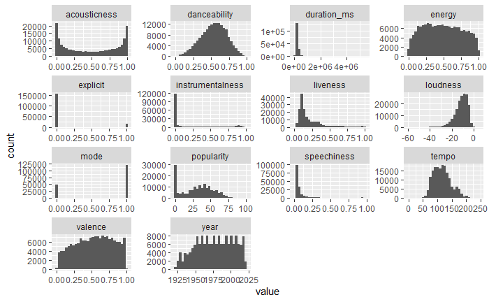

```r
# Histogram of all numeric features
df %>%
  keep(is.numeric) %>%
  gather() %>%
  ggplot(aes(value)) +
    facet_wrap(~ key, scales = "free") +
    geom_histogram()
```

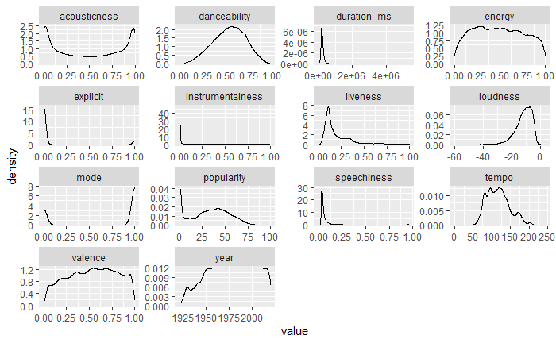

```r
# Density plot of all numeric features
df %>%
  keep(is.numeric) %>%
  gather() %>%
  ggplot(aes(value)) +
    facet_wrap(~ key, scales = "free") +
    geom_density()
```

##### Insights:

- The distribution of the duration of songs seems to stay largely within a certain range; the long right tail could be due to other audio products (e.g. audiobooks, podcasts, long instrumental songs)
- As expected, the distribution of explicitness and mode is bimodal because its values are binary, with songs being categorized as 0 or 1 for each of these values.
- There are significant differences in the distribution of features in the given songs; for instance, songs tend to score low on instrumentalness and speechiness due to the high density near the lower side of the scale. In contrast, the songs seem to score along an almost uniform distribution for energy and valence.
- The distribution of observations per year is also not uniform (with fewer observations in earlier years and in 2020), which confirms our initial description of this data frame as an unbalanced panel dataset.

#### Look at distribution of our key variable of interest, popularity

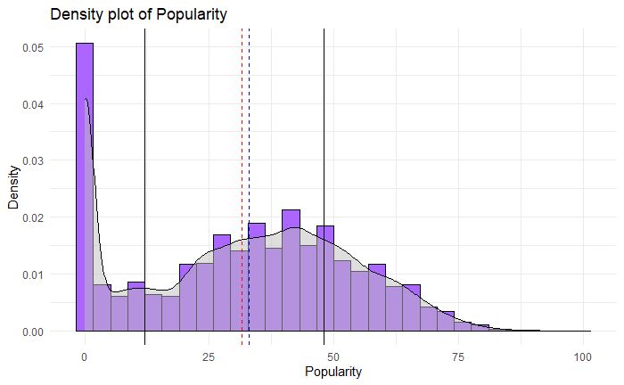

```r
popular_df <- data.frame(x = df$popularity)
Log_pol <- popular_df %>%
  ggplot(aes(x=x, fill = '#AA66FF'))+
  labs(title = "Density plot of Popularity", x = "Popularity", y = "Density")+
  geom_histogram(aes(y=..density..), color = 'black', fill='#AA66FF')+
  geom_density(aes(y=..density..),color = 'black',fill = 'grey',  alpha = 0.5,  kernel='gaussian')+
  geom_vline(aes(xintercept = mean(x)),color = 'red', linetype = 'dashed')+
  geom_vline(aes(xintercept = median(x)),color = 'blue', linetype = 'dashed')+
  geom_vline(aes(xintercept = quantile(x, probs = 0.25)),color = 'black')+
  geom_vline(aes(xintercept = quantile(x, probs = 0.75)),color = 'black')+
  theme_minimal()

Log_pol
```

#### Look at overlapping distribution of key features in a 0 - 1 continuous scale

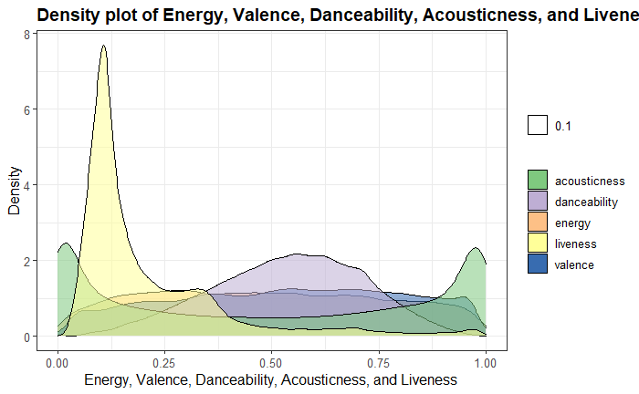

```r
correlated_density <- ggplot(df) +
    geom_density(aes(energy, fill ="energy", alpha = 0.1)) +
    geom_density(aes(valence, fill ="valence", alpha = 0.1)) +
    geom_density(aes(danceability, fill ="danceability", alpha = 0.1)) +
   geom_density(aes(acousticness, fill ="acousticness", alpha = 0.1)) +
  geom_density(aes(liveness, fill ="liveness", alpha = 0.1)) +
    scale_x_continuous(name = "Energy, Valence, Danceability, Acousticness, and Liveness") +
    scale_y_continuous(name = "Density") +
    ggtitle("Density plot of Energy, Valence, Danceability, Acousticness, and Liveness") +
    theme_bw() +
    theme(plot.title = element_text(size = 14, face = "bold"),
          text = element_text(size = 12)) +
    theme(legend.title=element_blank()) +
    scale_fill_brewer(palette="Accent")

correlated_density
```

##### Insights:

- This density plot overlaying the main features for the given songs enables us to see any potential relationships in the underlying distributions of these features.
- Acousticness has a bimodal distribution, with a large frequency of songs categorized at both ends of the spectrum.
- Liveness has a large frequency towards the lower end of the spectrum, but has a significant skew and long right tail.
- Danceability has a somewhat normal distribution but with large kurtosis.
- Valence and Energy have somewhat uniform distributions, with songs categorized evenly thoughout the spectrum.

#### Look at distribution of Songs by Key

```r
# Create key_val column to map key number to actual key
df$key <- as.character(df$key)
df$key_val <- revalue(df$key, c("0" = "C", "1" = "C♯,D♭", "2" = "D", "3" = "D♯,E♭", "4" = "E", "5" =  "F", "6" = "F♯,G♭","7" = "G","8" = "G♯,A♭","9" = "A","10" = "A♯,B♭","11" = "B"))
head(df$key_val)
```

```
[1] "G"     "A♯,B♭" "C"     "D♯,E♭" "C"     "C♯,D♭"
```

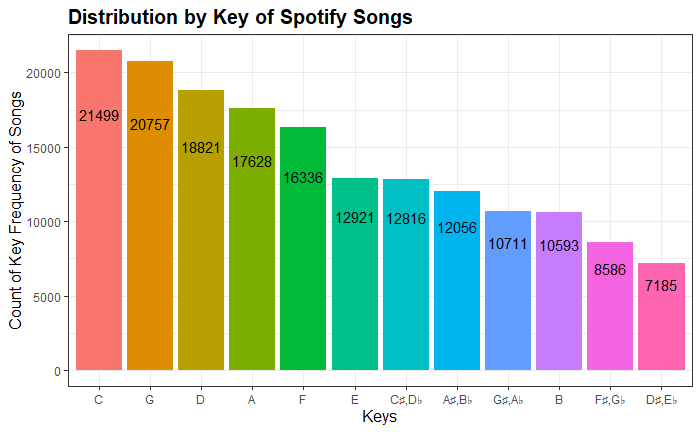

```r
# Plot distribution of keys
song_keys <- df %>%
    group_by(key_val) %>%
    dplyr::summarise(n_key = n()) %>%
    arrange(desc(n_key))
song_keys$key <- factor(song_keys$key_val, levels = song_keys$key_val[order(song_keys$n_key)]) # in order to visualise the keys in descending order

ggplot(song_keys, aes(x = reorder(key,-n_key), y = n_key, fill = reorder(key,-n_key))) +
    geom_bar(stat = "identity") +
    labs(title = "Distribution by Key of Spotify Songs", x = "Keys", y = "Count of Key Frequency of Songs") +
    geom_text(aes(label=n_key), position = position_stack(vjust = 0.8)) +
    theme_bw() +
    theme(plot.title = element_text(size=15,face = "bold"), axis.title = element_text(size=12)) +
    theme(legend.position="none")
```

The above chart illustrates the fact that songs are composed using they keys C,G, and D most frequently.

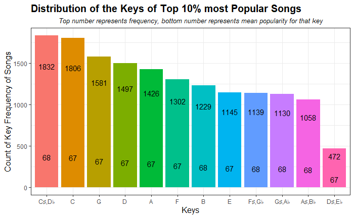

```r
# Plot Top Distribution of Keys for Top 10% of most popular songs
song_keys <- df %>%
    filter(quantile(popularity, 0.9)<popularity)%>% # Get Top Quantile of Songs
    group_by(key_val)%>%
    dplyr::summarise(n_key = n(), mean = mean(popularity)) %>%
    arrange(desc(n_key))
song_keys$key <- factor(song_keys$key_val, levels = song_keys$key_val[order(song_keys$n_key)]) # in order to visualise the keys in descending order

ggplot(song_keys, aes(x = reorder(key,-n_key), y = n_key, fill = reorder(key,-n_key))) +
    geom_bar(stat = "identity") +
    labs(title = "Distribution of the Keys of Top 10% most Popular Songs", x = "Keys", y = "Count of Key Frequency of Songs",subtitle="Top number represents frequency, bottom number represents mean popularity for that key") +
    geom_text(aes(label=n_key), position = position_stack(vjust = 0.8)) +
    geom_text(aes(label=round(mean)), position = position_stack(vjust = 0.2)) +
    theme_bw() +
    theme(plot.title = element_text(size=15,face = "bold"), axis.title = element_text(size=12)) +
    theme(plot.subtitle=element_text(size=10, hjust=0.5, face="italic", color="black"))+
    theme(legend.position="none")
```

This chart indicates that for the top 10% of the most popular songs, the most frequent key used is actually C sharp, C, and G.

#### Look at feature changes over time

```r
# Group df by year, take the mean value of each feature
start_year = min(df$year)
end_year = max(df$year)
trend_chart <- function(arg){
trend_change <- df  %>% group_by(year) %>% summarize_at(vars(all_of(arg)), funs(Average = mean))
chart<- ggplot(data = trend_change, aes(x = as.Date(year), y = Average)) +
     geom_line(color = "#00AFBB", size = 1)+ labs(x="Year")+
    scale_x_date(date_labels = "%Y") + scale_y_continuous(name=paste("",arg,sep=""))
return(chart)
}

# Plot trend over each year for each feature
trend_chart_track_popularity<-trend_chart("popularity")
```

[output not shown]

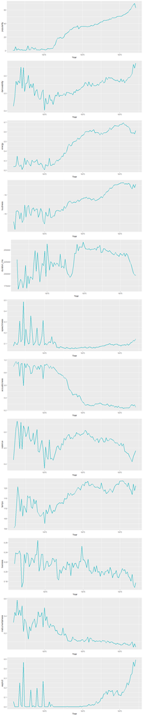

```r
trend_chart_acousticness <- trend_chart("acousticness")
trend_chart_danceability<-trend_chart("danceability")
trend_chart_energy<-trend_chart("energy")
trend_chart_loudness<-trend_chart("loudness")
trend_chart_valence <-trend_chart("valence")
trend_chart_tempo <-trend_chart("tempo")
trend_chart_duration_ms<-trend_chart("duration_ms")
trend_chart_speechiness<-trend_chart("speechiness")
trend_chart_liveness <-trend_chart("liveness")
trend_chart_instrumentalness <-trend_chart("instrumentalness")
trend_chart_explicit <- trend_chart("explicit")

plot_grid(trend_chart_track_popularity, trend_chart_danceability, trend_chart_energy, trend_chart_loudness, trend_chart_duration_ms, trend_chart_speechiness,trend_chart_acousticness,trend_chart_valence,trend_chart_tempo,trend_chart_liveness,trend_chart_instrumentalness,trend_chart_explicit, ncol = 1, label_size = 1)
```

##### Insights:

- Average popularity of songs increases over time. This is expected as newer released songs are more likely to get more plays on Spotify. This may also highlight the trends and popularity towards pop music.
- Danceability, Loudness, Explicitness, Energy, and Tempo on average have trended up over time, highlighting that more recent songs score higher on these metrics.
- In contrast, Instrumentalness, Liveness, and Acousticness have clearly trended down over time, highlighting that more recent songs score lower on these metrics.
- There is no clear trend in the rest of the remaining features.

#### Look at Correlation of Features

```r
# Extract all numeric values from df
numerics = df[,!(colnames(df)  %in% c("id","artists","name","release_date", "key_val"))]
numerics$key = as.integer(numerics$key)
tidyverse_static_correlations <- numerics %>% correlate()
```

```
Correlation method: 'pearson'
Missing treated using: 'pairwise.complete.obs'
```

```r
print.data.frame(tidyverse_static_correlations)
```

```
               term acousticness danceability  duration_ms      energy     explicit instrumentalness           key      liveness    loudness
1      acousticness           NA -0.265950251 -0.079311120 -0.75028307 -0.253689798       0.33582105 -0.0216864569 -0.0238705569 -0.56707180
2      danceability  -0.26595025           NA -0.134499848  0.22056881  0.241891382      -0.28142866  0.0225993022 -0.1055324762  0.29416994
3       duration_ms  -0.07931112 -0.134499848           NA  0.03639552 -0.043810866       0.08481437 -0.0031158466  0.0342700441 -0.01468714
4            energy  -0.75028307  0.220568806  0.036395525          NA  0.142677012      -0.28769152  0.0299837262  0.1262930218  0.78298168
5          explicit  -0.25368980  0.241891382 -0.043810866  0.14267701           NA      -0.13829157  0.0085776232  0.0392716150  0.15269523
6  instrumentalness   0.33582105 -0.281428663  0.084814371 -0.28769152 -0.138291574               NA -0.0142675248 -0.0473971355 -0.41703328
7               key  -0.02168646  0.022599302 -0.003115847  0.02998373  0.008577623      -0.01426752            NA -0.0001058318  0.02191986
8          liveness  -0.02387056 -0.105532476  0.034270044  0.12629302  0.039271615      -0.04739714 -0.0001058318            NA  0.05298457
9          loudness  -0.56707180  0.294169938 -0.014687139  0.78298168  0.152695230      -0.41703328  0.0219198644  0.0529845674          NA
10             mode   0.04647480 -0.045306423 -0.046981076 -0.03835485 -0.083220610      -0.03505096 -0.1127656100  0.0053933022 -0.01314666
11       popularity  -0.59334520  0.221076890  0.063291780  0.49748834  0.214044049      -0.29982923  0.0106749677 -0.0752927708  0.46654601
12      speechiness  -0.05607702  0.225304630 -0.058449073 -0.04522623  0.413074496      -0.11573490  0.0152252942  0.1476673853 -0.10579640
13            tempo  -0.20498168 -0.004871758 -0.028816023  0.24993569  0.011483541      -0.10757018  0.0031476254  0.0081239392  0.21111421
14          valence  -0.18553983  0.560242182 -0.198759541  0.35008554 -0.022327074      -0.19392918  0.0290643565 -0.0004263233  0.30841801
```

[output cut: 17 more lines]

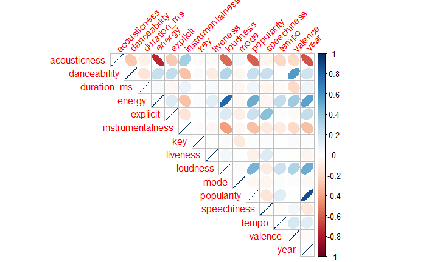

```r
# Correlation Plot
mtCor <- cor(numerics)
corrplot(mtCor, method = "ellipse", type = "upper", tl.srt = 45)
```

It can be seen that energy is highly correlated with loudness, and that year is highly correlated with popularity. On the other hand, acousticness is highly inversely correlated with energy, year, popularity, and loudness.

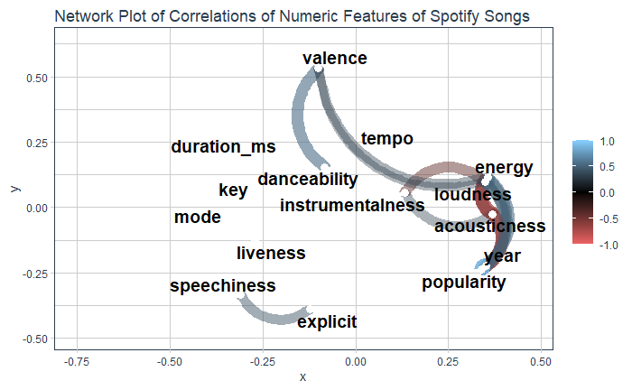

```r
# Network plot
# To interpret this plot, variables that are more highly correlated appear closer together and are joined by stronger paths. Paths are colored by their
# sign (positive = blue, red = negative).
net_plot <- tidyverse_static_correlations %>%
    network_plot(colours = c("indianred2", "black", "skyblue1"),repel=TRUE, legend = TRUE) +
    labs(
        title = "Network Plot of Correlations of Numeric Features of Spotify Songs"
        ) +
    expand_limits(x = c(-0.75, 0.25), y = c(-0.4, 0.4)) +
    theme_tq() +
    theme(legend.position = "right")
net_plot
```

From this network plot, it can be seen that popularity, year, acousticness, loudness and energy are more strongly correlated as they are grouped together. There seems to also be a positive correlation between speechiness and explicitness.

#### Build a K-means Clustering model to further analyze the features

We use a K-Means Clustering model as an unsupervised learning technique to determine how many natural “categories” of songs there are in the data. This is a dimensionality reduction technique used to group songs together.

We use the Elbow method to determine the optimal number of clusters, and we minimize the Within-cluster Sum-of-Squares.

```r
# Need to use all numeric values of relevant features and scale inputs
cluster.input <- numerics
cols <- colnames(cluster.input)
cluster.input.scaled <- scale(cluster.input[,cols])
head(cluster.input.scaled)
```

```
  acousticness danceability duration_ms     energy   explicit instrumentalness       key   liveness   loudness       mode popularity speechiness
1    0.6340119    1.6016940  -0.4193237 -0.5519771 -0.3045195       -0.5235112  0.511906 -0.2640909 -0.1889457  0.6413417  -1.137796   2.1405101
2    1.2977985   -1.4779353   4.9476700 -1.0381585 -0.3045195        2.3148917  1.365329  2.5923006 -1.5398047  0.6413417  -1.230463  -0.3832115
3    1.1889375   -1.6946499  -0.2893060 -0.8025475 -0.3045195       -0.5234869 -1.479414 -0.6125141  0.2859285 -1.5592222  -1.369464  -0.4292307
4    1.2314198   -0.6852159  -0.5334004 -1.1054759 -0.3045195       -0.5235058 -0.625991  0.1261883  0.2248707  0.6413417  -1.369464  -0.3738742
5    1.3349705   -0.1149142  -0.5926312 -1.0680773 -0.3045195       -0.5235112 -1.479414 -0.5186209  0.1378722  0.6413417  -1.230463  -0.2171421
6    1.3270051   -0.8506034  -0.1041292 -1.4981609 -0.3045195        1.1801771 -1.194939  0.8841219 -1.7153899 -1.5592222  -1.369464  -0.3231864
       tempo    valence      year
1 -1.8228962  1.6421201 -2.196806
2 -1.1714157 -1.8013773 -2.196806
3 -0.8518590 -1.2198393 -2.196806
4 -0.4973817 -1.0635938 -2.196806
5 -1.6508973 -0.4805315 -2.196806
6 -0.7837103 -1.7491684 -2.196806
```

Train clusters with various k-values (2-5)

```r
# kmeans with different k values
k2 <- kmeans(cluster.input.scaled, centers = 2, nstart = 25)
k3 <- kmeans(cluster.input.scaled, centers = 3, nstart = 25)
```

```
Quick-TRANSfer stage steps exceeded maximum (= 8495450)
```

```r
k4 <- kmeans(cluster.input.scaled, centers = 4, nstart = 25)
```

```
Quick-TRANSfer stage steps exceeded maximum (= 8495450)Quick-TRANSfer stage steps exceeded maximum (= 8495450)Quick-TRANSfer stage steps exceeded maximum (= 8495450)
```

```r
k5 <- kmeans(cluster.input.scaled, centers = 5, nstart = 25)
```

```
Quick-TRANSfer stage steps exceeded maximum (= 8495450)Quick-TRANSfer stage steps exceeded maximum (= 8495450)Quick-TRANSfer stage steps exceeded maximum (= 8495450)
```

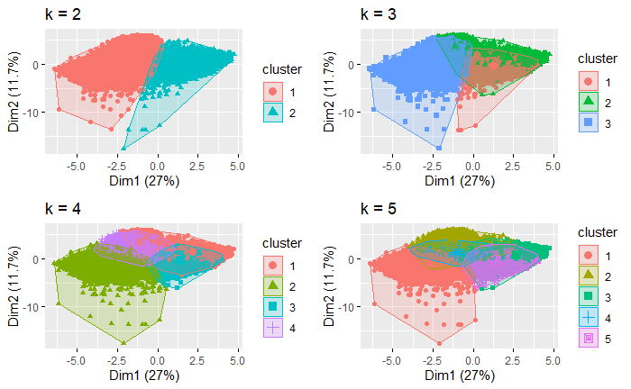

```r
# plots to compare
p1 <- fviz_cluster(k2, geom = "point",  data = cluster.input.scaled) + ggtitle("k = 2")
p2 <- fviz_cluster(k3, geom = "point",  data = cluster.input.scaled) + ggtitle("k = 3")
p3 <- fviz_cluster(k4, geom = "point",  data = cluster.input.scaled) + ggtitle("k = 4")
p4 <- fviz_cluster(k5, geom = "point",  data = cluster.input.scaled) + ggtitle("k = 5")

grid.arrange(p1, p2, p3, p4, nrow = 2)
```

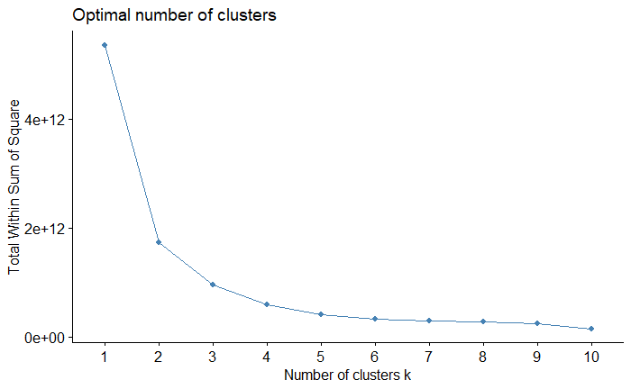

```r
# Visualize how WSS-metric is reduced as we increase the number of clusters
set.seed(100)
fviz_nbclust(cluster.input[1:1000,], kmeans, method = "wss")
```

Generate a table of WSS errors by number of clusters

```r
n_clust<-fviz_nbclust(cluster.input[1:1000,], kmeans, method = "wss")
n_clust<-n_clust$data
n_clust %>% rename(replace = c("y" = "Within_sum_of_squared_error", "clusters" = "Number_of_clusters")) %>%
  mutate(Within_sum_of_squared_error = color_tile("white", "red")(Within_sum_of_squared_error)) %>%
  kable("html", escape = F) %>%
  kable_styling("hover", full_width = F) %>%
  column_spec(2, width = "5cm") %>%
  row_spec(3:3, bold = T, color = "white", background = "grey")
```

| Number_of_clusters | Within_sum_of_squared_error |
| --- | --- |
| 1 | 5.351493e+12 |
| 2 | 1.731762e+12 |
| 3 | 9.516889e+11 |
| 4 | 6.026877e+11 |
| 5 | 4.169809e+11 |
| 6 | 3.319195e+11 |
| 7 | 2.942539e+11 |
| 8 | 2.769204e+11 |
| 9 | 2.548567e+11 |
| 10 | 1.542438e+11 |

##### Insights:

From this K-means cluster analysis, we can see that the within-cluster sum-of-squares error stabilizes when k becomes 3. Thus, this means that the features in the dataset can categorize the songs in 3 main categories; there is therefore a lot of commonalities from the features of the observed songs.

#### Time-series Visualization of all features

##### Plotting annual median values for each feature overall. Standardized such that each feature is on the same scale.

```r
q1s = data.frame(matrix(ncol=3, nrow=0))
medians = data.frame(matrix(ncol=3, nrow=0))
q3s = data.frame(matrix(ncol=3, nrow=0))
feature_names = sort(c("acousticness", "danceability", "instrumentalness", "energy",
                  "duration_ms", "valence", "tempo", "liveness", "loudness", "speechiness"))
for(i in 1921:2020){
  annual_val = subset(df, year==i)

  for(name in feature_names){
    vals = quantile(annual_val[,name])[2:4]
    q1s <- rbind(q1s, c(i, name, vals[1]))
    medians <- rbind(medians, c(i, name, vals[2]))
    q3s <- rbind(q3s, c(i, name, vals[3]))
  }
}

colnames(q1s) <-c("Year", "Feature", "Value")
colnames(medians) <-c("Year", "Feature", "Value")
colnames(q3s) <-c("Year", "Feature", "Value")

split_q1s <- split(q1s, q1s$Feature)
split_medians <- split(medians, medians$Feature)
split_q3s <- split(q3s, q3s$Feature)

feature_quantiles = array(0, c(100,3,length(feature_names)))

for(i in 1:length(feature_names)){
  for(j in 1:100){
    feature_quantiles[j,1,i] = split_q1s[[i]][[3]][j]
    feature_quantiles[j,2,i] = split_medians[[i]][[3]][j]
    feature_quantiles[j,3,i] = split_q3s[[i]][[3]][j]
  }
}

dimnames(feature_quantiles) <- list(1921:2020,
                                    c("Q1", "Median", "Q3"),
                                    feature_names)



plot(1930,1, xlim = c(1921,2020), ylim = range(0,15), xlab="Year", ylab="Range")
for(i in 1:length(feature_names)){
  name = feature_names[i]
  medians = as.numeric(feature_quantiles[,,name][,"Median"])

  avg = mean(medians)
  medians = medians / avg

  lines(x=1921:2020, y=medians, col=i)
}
```

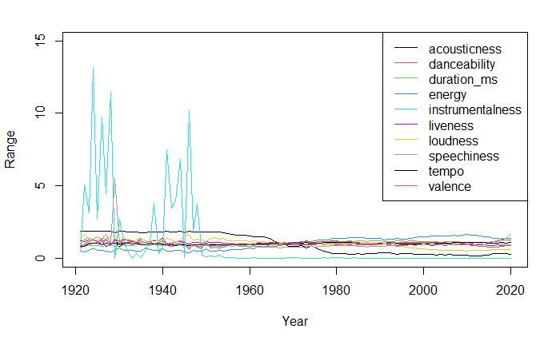

```r
legend("topright", lty=1, col=c(1,2,3,4,5,6,7,8,9,10), legend=feature_names)
```

##### Plotting annual median values for the feature for the *top 10% of songs* by popularity. Standardized such that each feature is on the same scale.

```r
q1s = data.frame(matrix(ncol=3, nrow=0))
medians = data.frame(matrix(ncol=3, nrow=0))
q3s = data.frame(matrix(ncol=3, nrow=0))
feature_names = sort(c("acousticness", "danceability", "instrumentalness", "energy",
                  "duration_ms", "valence", "tempo", "liveness", "loudness", "speechiness"))
for(i in 1921:2020){
  annual_val = subset(df, year==i)


  top_10 = floor(nrow(annual_val)*0.1)
  annual_val = annual_val[order(annual_val$popularity, decreasing=TRUE),]
  annual_val = annual_val[1:top_10,]

  for(name in feature_names){
    vals = quantile(annual_val[,name])[2:4]
    q1s <- rbind(q1s, c(i, name, vals[1]))
    medians <- rbind(medians, c(i, name, vals[2]))
    q3s <- rbind(q3s, c(i, name, vals[3]))
  }
}

colnames(q1s) <-c("Year", "Feature", "Value")
colnames(medians) <-c("Year", "Feature", "Value")
colnames(q3s) <-c("Year", "Feature", "Value")

split_q1s <- split(q1s, q1s$Feature)
split_medians <- split(medians, medians$Feature)
split_q3s <- split(q3s, q3s$Feature)

feature_quantiles = array(0, c(100,3,length(feature_names)))

for(i in 1:length(feature_names)){
  for(j in 1:100){
    feature_quantiles[j,1,i] = split_q1s[[i]][[3]][j]
    feature_quantiles[j,2,i] = split_medians[[i]][[3]][j]
    feature_quantiles[j,3,i] = split_q3s[[i]][[3]][j]
  }
}

dimnames(feature_quantiles) <- list(1921:2020,
                                    c("Q1", "Median", "Q3"),
                                    feature_names)


plot(1930,1, xlim = c(1921,2020), ylim = range(0,17), xlab="Year", ylab="Range")
for(i in 1:length(feature_names)){
  name = feature_names[i]
  medians = as.numeric(feature_quantiles[,,name][,"Median"])
  avg = mean(medians)
  medians = medians / avg

  lines(x=1921:2020, y=medians, col=i)
}
```

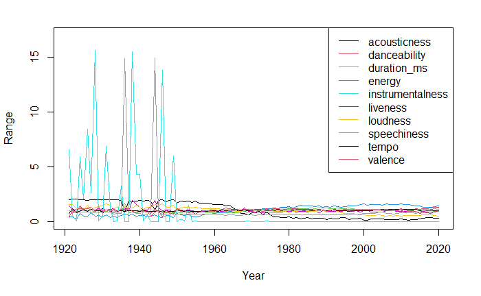

```r
legend("topright", lty=1, col=c(1,2,3,4,5,6,7,8,9,10), legend=feature_names)
```

#### Insights:

Both these graphs appear to have similar shapes, with instrumentalness being the most widely varying, and the rest varying marginally. However, for the speechiness variable, for the overall set of songs its median value varies much less than the median value for the most popular songs.

##### Now plotting absolute values for each feature as the median values for overall, as well as just the most popular songs.

- MAPE is the difference between the most popular median and the overall median; R is the correlation between overall median and most popular median.
- These values will determine whether or not the overall median is a useful predictor of what the median for popular songs will be. This is important because it will be easier to forecast overall values into the future, given they are much smoother, and these forecast overall values can be used to predict the most popular feature value.

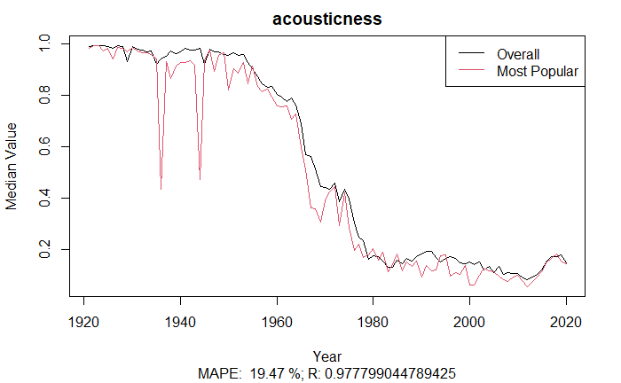

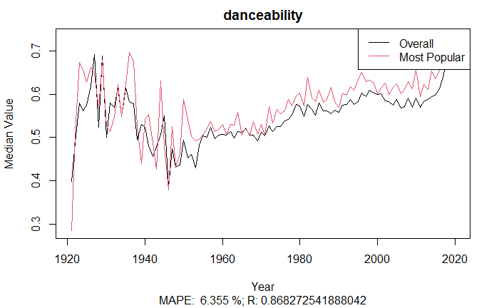

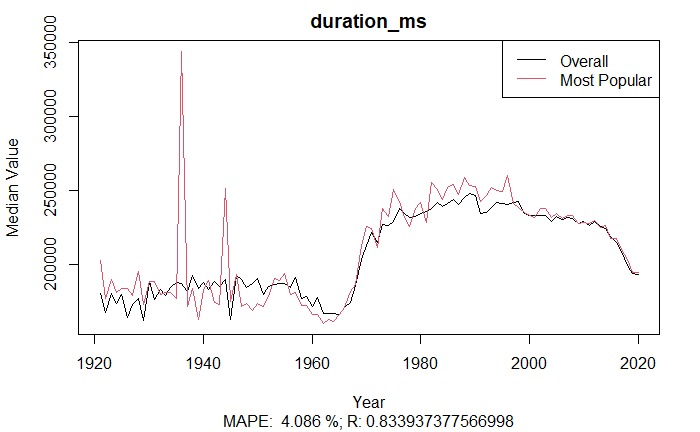

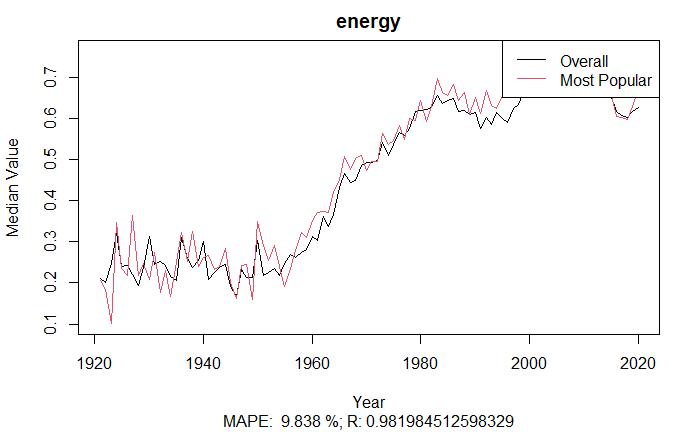

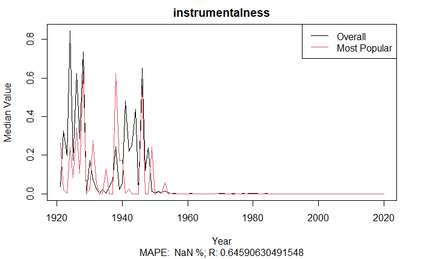

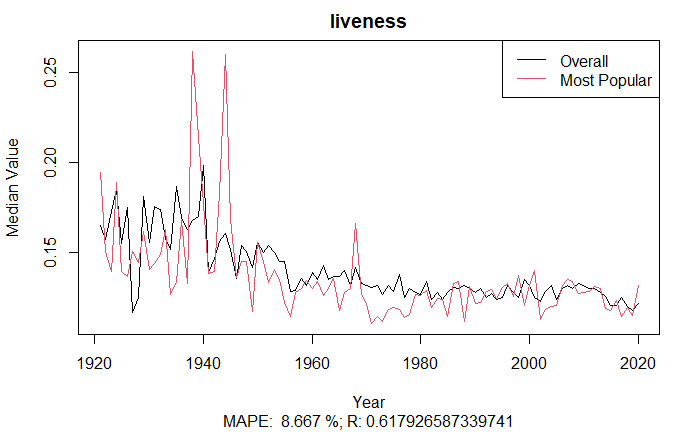

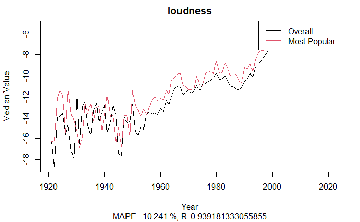

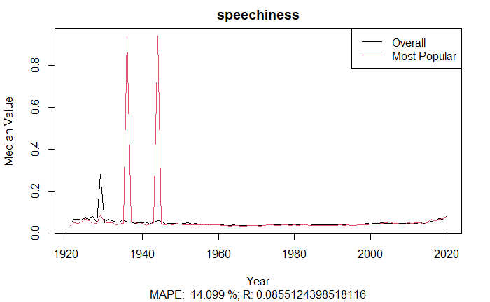

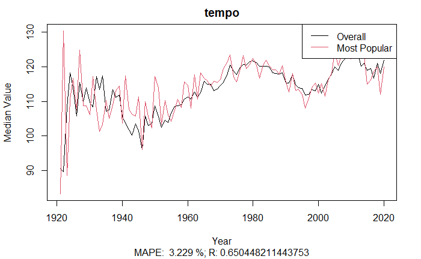

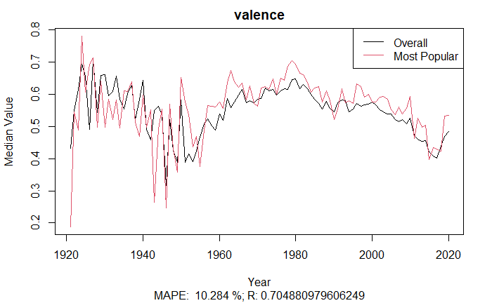

```r
# Get the list of features I need to work with

q1s = data.frame(matrix(ncol=3, nrow=0))
medians = data.frame(matrix(ncol=3, nrow=0))
best_medians = data.frame(matrix(ncol=3, nrow=0))
q3s = data.frame(matrix(ncol=3, nrow=0))
feature_names = sort(c("acousticness", "danceability", "instrumentalness", "energy",
                  "duration_ms", "valence", "tempo", "liveness", "loudness", "speechiness"))
for(i in 1921:2020){
  annual_val = subset(df, year==i)
  top_10 = floor(nrow(annual_val)*0.1)
  annual_val = annual_val[order(annual_val$popularity, decreasing=TRUE),]
  best_ones = annual_val[1:top_10,]

  for(name in feature_names){
    vals = quantile(annual_val[,name])[2:4]
    best_vals = quantile(best_ones[,name])[2:4]
    best_medians <- rbind(best_medians, c(i, name, best_vals[2]))
    medians <- rbind(medians, c(i, name, vals[2]))
  }
}

colnames(medians) <-c("Year", "Feature", "Value")
colnames(best_medians) <- c("Year", "Feature", "Value")

split_medians <- split(medians, medians$Feature)
split_best_medians <- split(best_medians, best_medians$Feature)

feature_quantiles = matrix(0, ncol=length(feature_names), nrow=100)
best_feature_quantiles = matrix(0, ncol=length(feature_names), nrow=100)

for(i in 1:length(feature_names)){
  for(j in 1:100){
    feature_quantiles[j,i] <- split_medians[[i]][[3]][j]
    best_feature_quantiles[j,i] = split_best_medians[[i]][[3]][j]
  }
}

dimnames(feature_quantiles) <- list(1921:2020,
                                    feature_names)
dimnames(best_feature_quantiles) <- list(1921:2020,
                                    feature_names)




for(i in 1:length(feature_names)){
  name = feature_names[i]
  scores = as.numeric(feature_quantiles[,i])
  best_scores = as.numeric(best_feature_quantiles[,i])
  mape = mape(best_scores, scores)
  mape = round(mape * 100,3)
  r  = cor(scores, best_scores)
  pval = t.test(scores, )
  # Normalize it????? / make it a function of its own mean

  smallest = min(min(scores), min(best_scores))
  biggest = max(max(scores), max(best_scores))

  plot(x=1921:2020, y=scores, col=1, type="l", ylim=c(smallest, biggest), main=name, sub=paste("MAPE: ", mape, "%;", "R:", r), xlab="Year", ylab="Median Value")
  lines(x=1921:2020, y=best_scores, col=2)
  legend("topright", lty=1, col=c(1,2), legend=c("Overall", "Most Popular"))
  title()
}
```

##### Insights:

**Acousticness**: A high MAPE when comparing the most popular songs with the overall trends indicates that there is a large difference between the two (likely caused in the 1930s-1950s). The R value is high which means there is a high correlation between the most popular songs and the overall songs. Because acousticness seems to impact popular songs and there is a large change over time, we will move forward with predicting the acousticness of songs in the future.

**Danceability**: A low MAPE indicates not a lot of difference between popular songs and overall songs danceability. However, a high R value means there is a high correlation between the most popular songs and the overall songs. Because danceability seems to impact popular songs (due to the high correlation) and there is a some change over time, we will move forward with predicting the danceability of songs in the future.

**Duration (ms)**: There is a low MAPE which means that popular songs have about the same length as all other songs. The R value is relatively high which means there is a high correlation between the most popular songs and the overall songs. Because duration seems to impact popular songs (due to the high correlation) and there is a some change over time, we will move forward with predicting the duration of songs in the future.

**Energy**: A high MAPE when comparing the most popular songs with the overall trends indicates that there is a large difference between the two. The R value is high which means there is a high correlation between the most popular songs and the overall songs. Because energy seems to impact popular songs (due to the high MAPE and correlation) and there are large changes over time, we will move forward with predicting the energy of songs in the future.

**Instrumentalness**: The popular songs and overall music trends are pretty much the exact same after the 1950s, indicating that instrumentalness does not affect popularity. Because instrumentalness does not impact popular songs and there is a flatline after the 1950s (indicating no change over time), we will not move forward with predicting the instrumentalness of songs in the future.

**Loudness**: A high MAPE when comparing the most popular songs with the overall trends indicates that there is a large difference between the two. The R value is high which means there is a high correlation between the most popular songs and the overall songs. Because loudness seems to impact popular songs (due to the high MAPE and correlation) and there is a significant change over time, we will move forward with predicting the loudness of songs in the future.

**Speechiness**: A high MAPE when comparing the most popular songs with the overall trends indicates that there is a large difference between the two. It’s important to note that the driver of the high MAPE is due to the two large spikes between 1930 and 1950, while speechiness levels between popular songs and the overall industry in the last 70 years have generally been the same. The R value is low which means there is a low correlation between the most popular songs and the overall songs. We will not move forward with predicting speechiness, due to the lack of change in speechiness over time and low R.

**Tempo**: The MAPE is low, inidcating that there isn’t a significant difference in tempo between the popular songs and the overall music trends. The R is relatively high, so there is possibly a correlation between popular songs and the overall songs. Because tempo seems to impact popular songs (due to the high correlation) and there is a some change over time, we will move forward with predicting the tempo of songs in the future.

**Valence**: A high MAPE when comparing the most popular songs with the overall trends indicates that there is a large difference between the two in terms of valence. The R value is high which means there is a high correlation between the most popular songs and the overall songs. Because valence seems to impact popular songs (due to the high MAPE and high correlation) and there is a some change over time, we will move forward with predicting the valence of songs in the future.

## **Model Building**

### Timeseries trend Predictions

#### Train time series models to forecast future feature trends

```r
# Set up the libraries and the training/testing amounts
training.percent = 0.95
nTrain = 100*training.percent
nTest = 100*(1-training.percent)
```

#### Acousticness Models

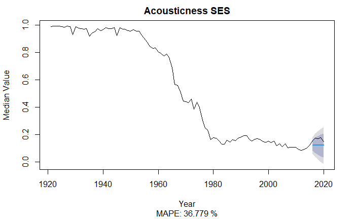

```r
acousticness = ts(as.numeric(feature_quantiles[,"acousticness"]) , start=1921)
acousticness.train = subset(acousticness, start=1, end=nTrain)
acousticness.test = subset(acousticness, start = (nTrain+1), end =(nTrain+nTest))

#ses
acousticness.train.ses <- ses(acousticness.train, h=nTest)
acousticness.ses.mape = mape(acousticness.train.ses$mean, acousticness.test)
plot(acousticness.train.ses, main=paste("Acousticness", "SES"), sub=paste("MAPE:", round(acousticness.ses.mape*100, 3), "%"), xlab="Year", ylab="Median Value")
lines(acousticness)
```

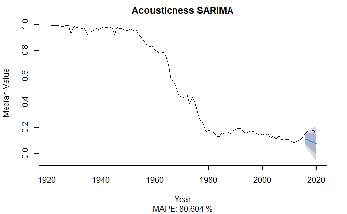

```r
#SARIMA
acousticness.sarima.model <- auto.arima(acousticness.train)
acousticness.sarima <- forecast(acousticness.sarima.model, h=nTest)
acousticness.sarima.mape = mape(acousticness.sarima$mean, acousticness.test)
plot(acousticness.sarima, main=paste("Acousticness", "SARIMA"), sub=paste("MAPE:", round(acousticness.sarima.mape*100,3), "%"), xlab="Year", ylab="Median Value")
lines(acousticness)
```

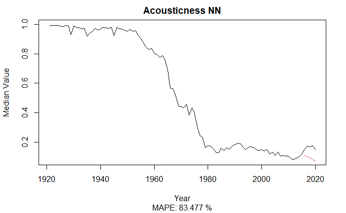

```r
#Neural Network
acousticness.train.nn <- elm(acousticness.train)
acousticness.nn.forecast <- forecast(acousticness.train.nn, h=nTest)
acousticness.nn.mape = mape(acousticness.nn.forecast$mean, acousticness.test)
plot(acousticness, main=paste("Acousticness", "NN"), sub=paste("MAPE:", round(acousticness.nn.mape*100, 3), "%"), xlab="Year", ylab="Median Value")
lines(ts(acousticness.nn.forecast$mean, start=1921+nTrain), col=2)
```

Here we see that the best method to predict future acousticness median values for the overall data set is through SES. However, given that this best MAPE is roughly 37%, this feature cannot be reliably forecast into the future.

#### Energy models

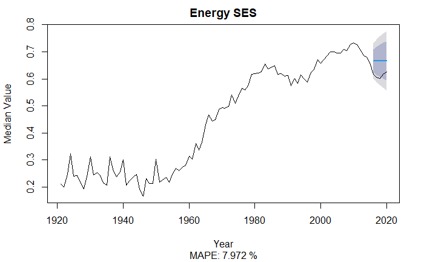

```r
energy = ts(as.numeric(feature_quantiles[,"energy"]) , start=1921)
energy.train = subset(energy, start=1, end=nTrain)
energy.test = subset(energy, start = (nTrain+1), end =(nTrain+nTest))

#SES
energy.train.ses <- ses(energy.train, h=nTest)
energy.ses.mape = mape(energy.train.ses$mean, energy.test)
plot(energy.train.ses, main=paste("Energy", "SES"), sub=paste("MAPE:", round(energy.ses.mape* 100, 3), "%"), xlab="Year", ylab="Median Value")
lines(energy)
```

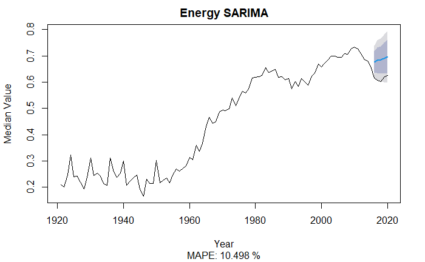

```r
#SARIMA
energy.sarima.model <- auto.arima(energy.train)
energy.sarima <- forecast(energy.sarima.model, h=nTest)
energy.sarima.mape = mape(energy.sarima$mean, energy.test)
plot(energy.sarima, main=paste("Energy", "SARIMA"), sub=paste("MAPE:", round(energy.sarima.mape* 100, 3), "%"), xlab="Year", ylab="Median Value")
lines(energy)
```

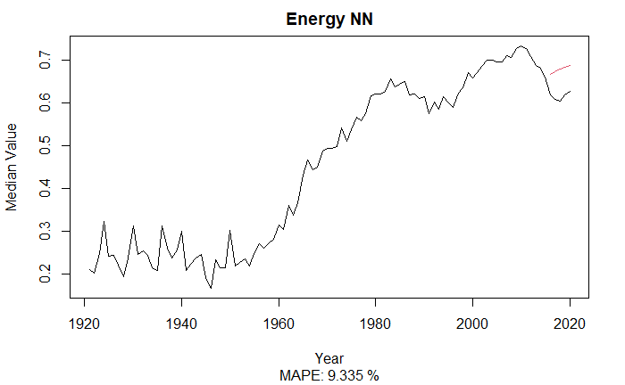

```r
#Neural Network
energy.train.nn <- elm(energy.train)
energy.nn.forecast <- forecast(energy.train.nn, h=nTest)
energy.nn.mape = mape(energy.nn.forecast$mean, energy.test)
plot(energy, main=paste("Energy", "NN"), sub=paste("MAPE:", round(energy.nn.mape* 100, 3), "%"), xlab="Year", ylab="Median Value")
lines(ts(energy.nn.forecast$mean, start=1921+nTrain), col=2)
```

Here we see that the best method to predict future energy median values for the overall data set is through SES. Given that this best MAPE is roughly 8%, this feature can be fairly reliably forecast into the future.

#### Danceability models

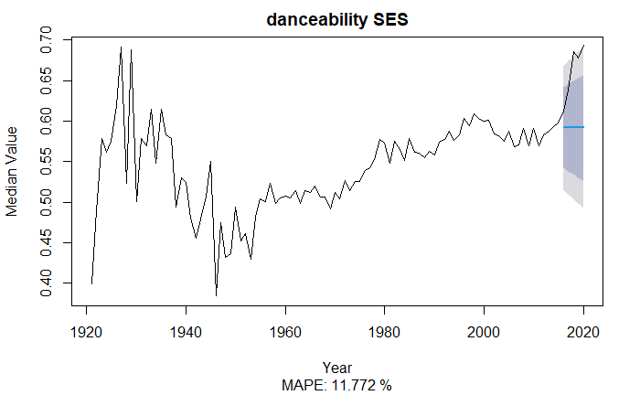

```r
danceability = ts(as.numeric(feature_quantiles[,"danceability"]) , start=1921)
danceability.train = subset(danceability, start=1, end=nTrain)
danceability.test = subset(danceability, start = (nTrain+1), end =(nTrain+nTest))

#SES
danceability.train.ses <- ses(danceability.train, h=nTest)
danceability.ses.mape = mape(danceability.train.ses$mean, danceability.test)
plot(danceability.train.ses, main=paste("danceability", "SES"), sub=paste("MAPE:", round(danceability.ses.mape* 100, 3), "%"), xlab="Year", ylab="Median Value")
lines(danceability)
```

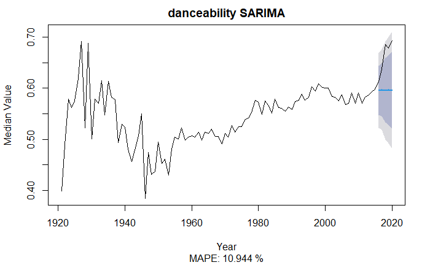

```r
#SARIMA
danceability.sarima.model <- auto.arima(danceability.train)
danceability.sarima <- forecast(danceability.sarima.model, h=nTest)
danceability.sarima.mape = mape(danceability.sarima$mean, danceability.test)
plot(danceability.sarima, main=paste("danceability", "SARIMA"), sub=paste("MAPE:", round(danceability.sarima.mape* 100, 3), "%"), xlab="Year", ylab="Median Value")
lines(danceability)
```

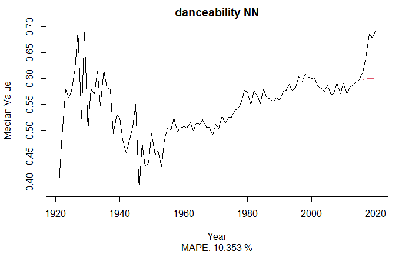

```r
#Neural Network
danceability.train.nn <- elm(danceability.train)
danceability.nn.forecast <- forecast(danceability.train.nn, h=nTest)
danceability.nn.mape = mape(danceability.nn.forecast$mean, danceability.test)
plot(danceability, main=paste("danceability", "NN"), sub=paste("MAPE:", round(danceability.nn.mape* 100, 3), "%"), xlab="Year", ylab="Median Value")
lines(ts(danceability.nn.forecast$mean, start=1921+nTrain), col=2)
```

Here we see that the best method to predict future danceability median values for the overall data set is through NN. However, given that this best MAPE is roughly 10.4%, this feature cannot be reliably forecast into the future.